# Myocardial infarction or heart attack

# 1 Description of DataSchema variable

The description of harmonised variable is the following:

- Short name: `mi_ha`
- Variable label: `Myocardial infarction or heart attack`
- Variable description: `Myocardial infarction or heart attack since the last wave`
- Domain: `Diseases`
- Value type: `categorical`
- Category coding:

| **Code** | **Category Label** |
| --- | --- |
| 0 | No |
| 1 | Yes |

- Category missings:

| **Code** | **Category Label** |
| --- | --- |
| 991 | CAPI/interviewer error |
| 992 | Impute |
| 993 | Disable to measure |
| 994 | Not attempt/not done |
| 995 | Does not answer |
| 996 | Not applicable |
| 997 | Refuse |
| 998 | Do not know |
| 999 | Missing |

- Short name: `mi_ha_age`
- Variable label: `Age of each episode of myocardial infarction or heart attack`
- Variable description: `Age of each episode of myocardial infarction or heart attack`
- Domain: `Diseases`
- Value type: `Continuous`
- Category missings:

| **Code** | **Category Label** |
| --- | --- |
| 991 | CAPI/interviewer error |
| 992 | Impute |
| 993 | Disable to measure |
| 994 | Not attempt/not done |
| 995 | Does not answer |
| 996 | Not applicable |
| 997 | Refuse |
| 998 | Do not know |
| 999 | Missing |

# 2 Data process

## 2.1 England

### 2.1.1 Wave 1

#### 2.1.1.1 Study-specific variable description

| **Name** | `hedim01` | `hedim02` | `hedim03` | `hedim04` | `hedim05` | `hedim06` | `hedim07` | `heagb` |
| --- | --- | --- | --- | --- | --- | --- | --- | --- |
| **Label** | `MERGED - Has a doctor ever told you that you [have/have had] any of the conditions in this card? {heart conditions}` | `MERGED - Has a doctor ever told you that you [have/have had] any of the conditions in this card? {heart conditions}` | `MERGED - Has a doctor ever told you that you [have/have had] any of the conditions in this card? {heart conditions}` | `MERGED - Has a doctor ever told you that you [have/have had] any of the conditions in this card? {heart conditions}` | `MERGED - Has a doctor ever told you that you [have/have had] any of the conditions in this card? {heart conditions}` | `MERGED - Has a doctor ever told you that you [have/have had] any of the conditions in this card? {heart conditions}` | `MERGED - Has a doctor ever told you that you [have/have had] any of the conditions in this card? {heart conditions}` | `Approximately how old were you when first told by a doctor that you had a heart attack (including mycardial infarction or thrombosis)? {years}` |
| **Table name** | `wave_1_core_data_v3` | `wave_1_core_data_v3` | `wave_1_core_data_v3` | `wave_1_core_data_v3` | `wave_1_core_data_v3` | `wave_1_core_data_v3` | `wave_1_core_data_v3` | `wave_1_core_data_v3` |
| **Categories** | `1 = High blood pressure or hypertension` `2 = Angina` `3 = A heart attack (including myocardial infarction or coronary)` `4 = Congestive heart failure` `5 = A heart murmur` `6 = An abnormal heart rhy… | `1 = High blood pressure or hypertension` `2 = Angina` `3 = A heart attack (including myocardial infarction or coronary)` `4 = Congestive heart failure` `5 = A heart murmur` `6 = An abnormal heart rhy… | `1 = High blood pressure or hypertension` `2 = Angina` `3 = A heart attack (including myocardial infarction or coronary)` `4 = Congestive heart failure` `5 = A heart murmur` `6 = An abnormal heart rhy… | `1 = High blood pressure or hypertension` `2 = Angina` `3 = A heart attack (including myocardial infarction or coronary)` `4 = Congestive heart failure` `5 = A heart murmur` `6 = An abnormal heart rhy… | `1 = High blood pressure or hypertension` `2 = Angina` `3 = A heart attack (including myocardial infarction or coronary)` `4 = Congestive heart failure` `5 = A heart murmur` `6 = An abnormal heart rhy… | `1 = High blood pressure or hypertension` `2 = Angina` `3 = A heart attack (including myocardial infarction or coronary)` `4 = Congestive heart failure` `5 = A heart murmur` `6 = An abnormal heart rhy… | `1 = High blood pressure or hypertension` `2 = Angina` `3 = A heart attack (including myocardial infarction or coronary)` `4 = Congestive heart failure` `5 = A heart murmur` `6 = An abnormal heart rhy… | `continuous` |
| **Missings** | `-9 = Refusal` `-8 = Don't know` `-1 = Not applicable` | `-9 = Refusal` `-8 = Don't know` `-1 = Not applicable` | `-9 = Refusal` `-8 = Don't know` `-1 = Not applicable` | `-9 = Refusal` `-8 = Don't know` `-1 = Not applicable` | `-9 = Refusal` `-8 = Don't know` `-1 = Not applicable` | `-9 = Refusal` `-8 = Don't know` `-1 = Not applicable` | `-9 = Refusal` `-8 = Don't know` `-1 = Not applicable` | `-9 = Refusal` `-8 = Don't know` `-1 = Not applicable` |
| **Description** |  |  |  |  |  |  |  |  |

hedim01

| Sample size | Missing values |
| --- | --- |
| 12099 | 9 |

Category

|  | 1 | 2 | 3 | 4 | 5 | 6 | 7 | 8 | 85 | 86 | 96 |
| --- | --- | --- | --- | --- | --- | --- | --- | --- | --- | --- | --- |
| Frequency | 4474.00 | 486.00 | 168.00 | 21.00 | 248.00 | 276.00 | 218.0 | 98.00 | 16.00 | 10.00 | 6075.00 |
| Percentage | 36.98 | 4.02 | 1.39 | 0.17 | 2.05 | 2.28 | 1.8 | 0.81 | 0.13 | 0.08 | 50.21 |

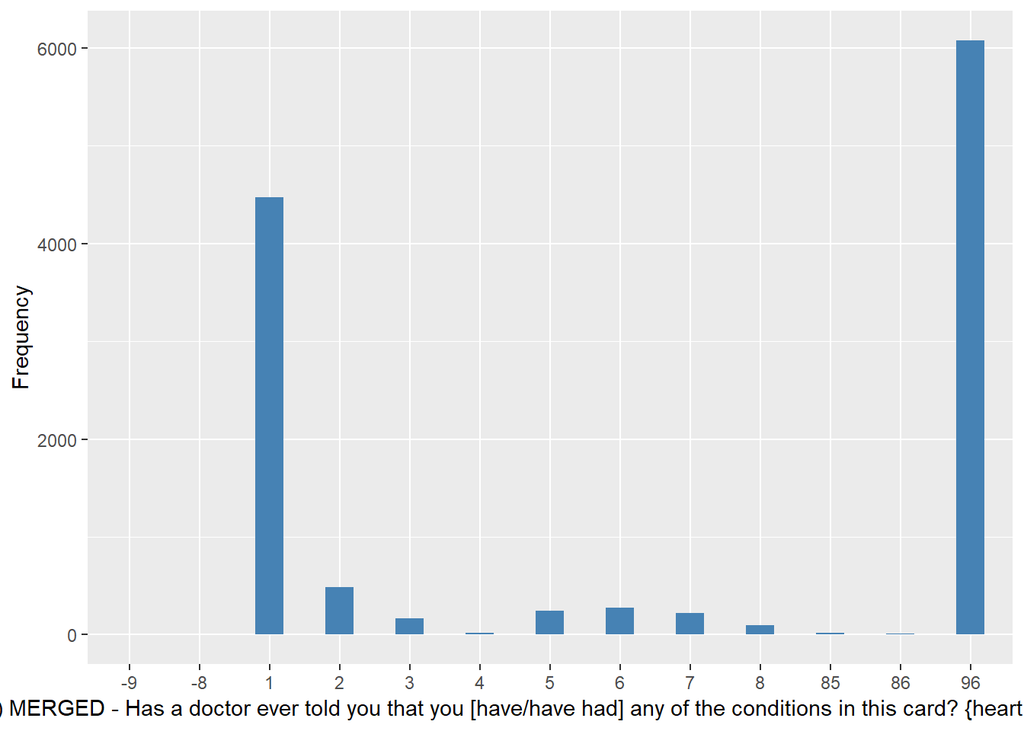

hedim02

| Sample size | Missing values |
| --- | --- |
| 12099 | 9973 |

Category

|  | 2 | 3 | 4 | 5 | 6 | 7 | 8 | 85 | 86 | 96 |
| --- | --- | --- | --- | --- | --- | --- | --- | --- | --- | --- |
| Frequency | 661.00 | 286.00 | 42.00 | 205.00 | 283.00 | 413.00 | 198.00 | 20.00 | 16.00 | 2.00 |
| Percentage | 5.46 | 2.36 | 0.35 | 1.69 | 2.34 | 3.41 | 1.64 | 0.17 | 0.13 | 0.02 |

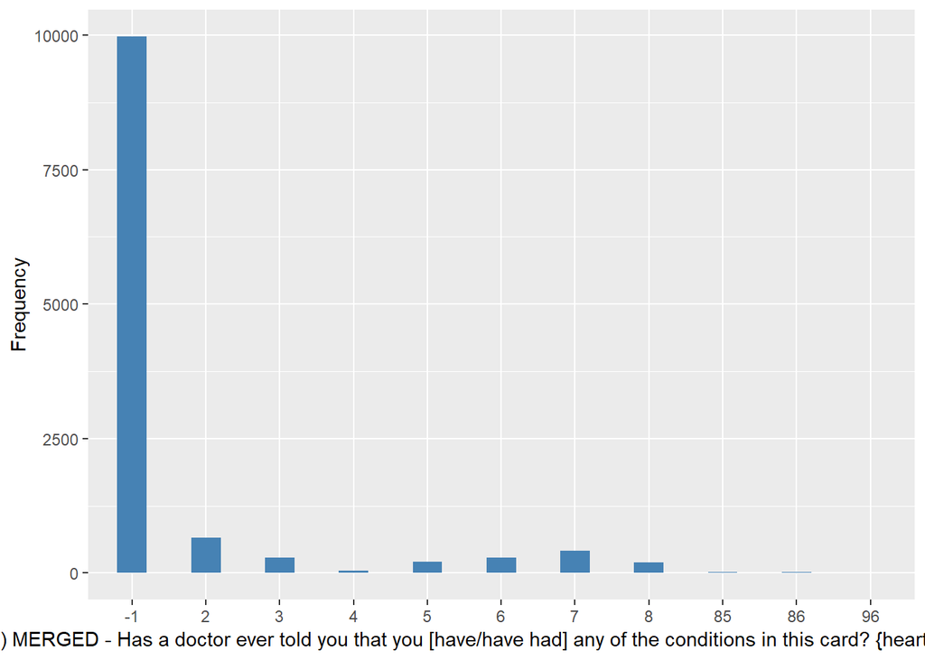

hedim03

| Sample size | Missing values |
| --- | --- |
| 12099 | 11350 |

Category

|  | 3 | 4 | 5 | 6 | 7 | 8 | 85 | 86 | 96 |
| --- | --- | --- | --- | --- | --- | --- | --- | --- | --- |
| Frequency | 248.00 | 26.00 | 69.00 | 117.00 | 151.00 | 112.00 | 19.00 | 6.00 | 1.00 |
| Percentage | 2.05 | 0.21 | 0.57 | 0.97 | 1.25 | 0.93 | 0.16 | 0.05 | 0.01 |

[figure not shown]

hedim04

| Sample size | Missing values |
| --- | --- |
| 12099 | 11837 |

Category

|  | 4 | 5 | 6 | 7 | 8 | 85 |
| --- | --- | --- | --- | --- | --- | --- |
| Frequency | 20.00 | 24.0 | 70.00 | 67.00 | 70.00 | 11.00 |
| Percentage | 0.17 | 0.2 | 0.58 | 0.55 | 0.58 | 0.09 |

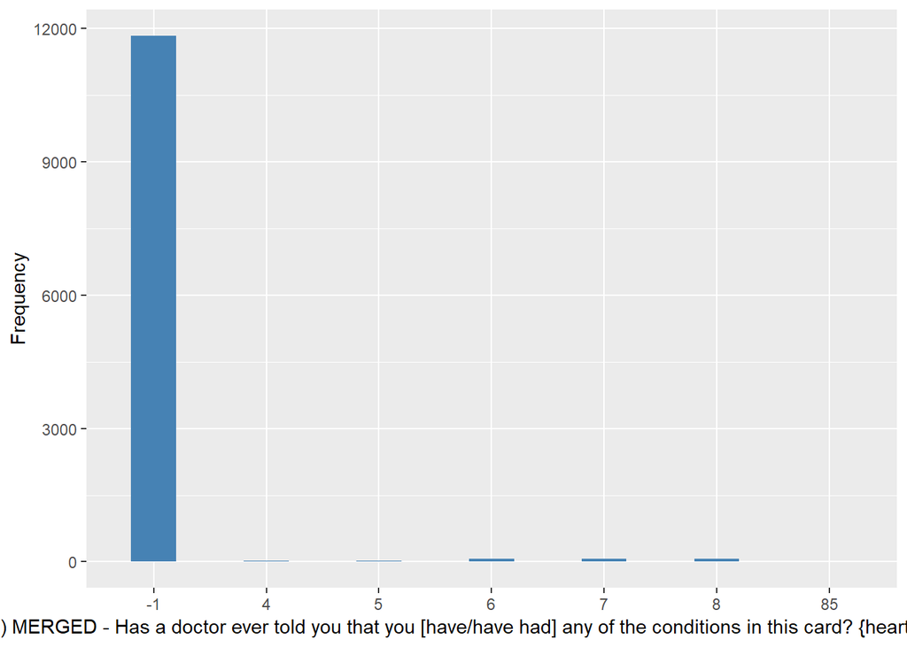

hedim05

| Sample size | Missing values |
| --- | --- |
| 12099 | 12027 |

Category

|  | 5 | 6 | 7 | 8 | 85 | 86 |
| --- | --- | --- | --- | --- | --- | --- |
| Frequency | 9.00 | 12.0 | 16.00 | 32.00 | 2.00 | 1.00 |
| Percentage | 0.07 | 0.1 | 0.13 | 0.26 | 0.02 | 0.01 |

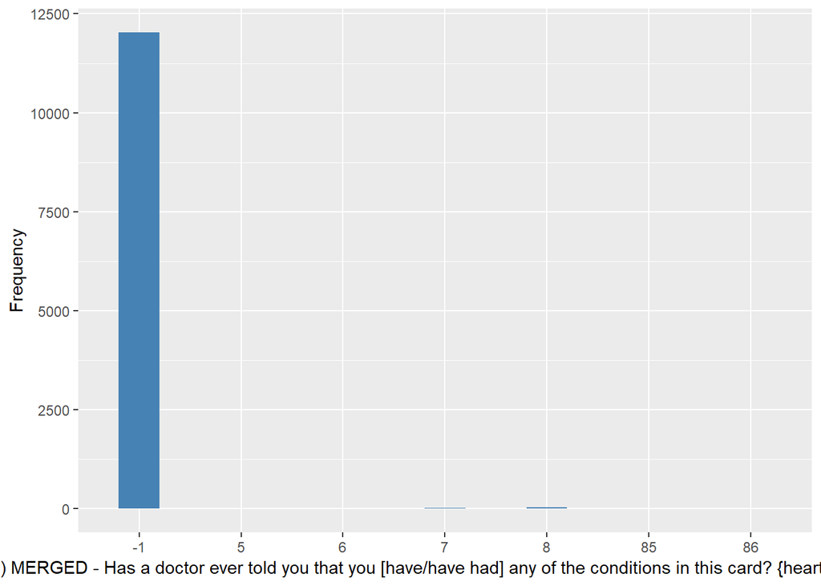

hedim06

| Sample size | Missing values |
| --- | --- |
| 12099 | 12090 |

Category

|  | 6 | 7 | 8 |
| --- | --- | --- | --- |
| Frequency | 5.00 | 1.00 | 3.00 |
| Percentage | 0.04 | 0.01 | 0.02 |

[figure not shown]

hedim07

| Sample size | Missing values |
| --- | --- |
| 12099 | 12096 |

Category

|  | 8 |
| --- | --- |
| Frequency | 3.00 |
| Percentage | 0.02 |

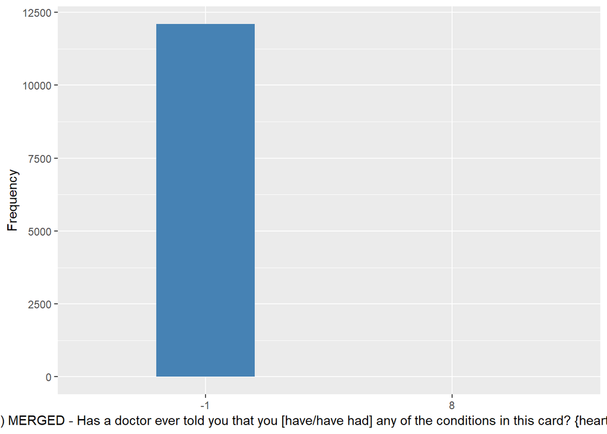

heagb

| Sample size | Missing values |
| --- | --- |
| 12099 | 11598 |

Summary

| Min. | 1st Qu. | Median | Mean | 3rd Qu. | Max. |
| --- | --- | --- | --- | --- | --- |
| 16 | 53 | 61 | 60.29 | 69 | 91 |

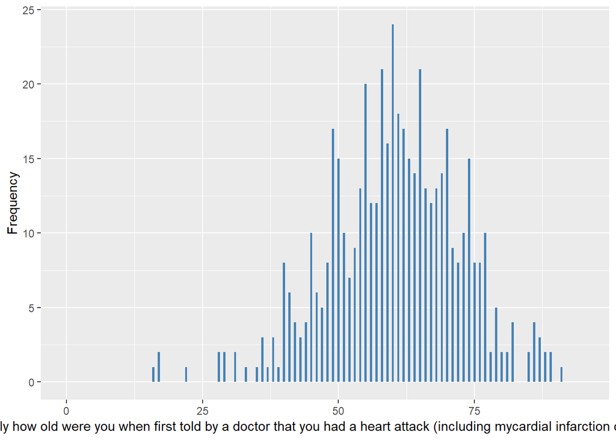

#### 2.1.1.2 Harmonisation algorithm

To compute `mi_ha` from the study-specific variable it has to be recoded as follows:

- `some hedimX == 3 into 1`
- `-9 into 997`
- `-8 into 998`
- `otherwise into 0`

To compute `mi_ha_age` from the study-specific variable it has to be recoded as follows:

- `if mi_ha == 1, mi_ha_age = heagb`
- `if mi_ha == 0, mi_ha_age = 996`
- `-9 into 997`
- `-8 into 998`
- `-1 into 996`
- `otherwise, mi_ha_age = 999`

**R script:**

```r
# Categorical variable harmonization
ELSA_ds_w1 <- tibble(id = ELSA_w1$id)
ELSA_ds_w1$mi_ha <- rep(0, length(ELSA_w1$id))
ELSA_ds_w1$mi_ha[which(ELSA_w1$hedim01 == 3 | ELSA_w1$hedim02 == 3 | ELSA_w1$hedim03 ==
    3 | ELSA_w1$hedim04 == 3 | ELSA_w1$hedim05 == 3 | ELSA_w1$hedim06 == 3 |
    ELSA_w1$hedim07 == 3)] <- 1
ELSA_ds_w1$mi_ha[which(ELSA_w1$hedim01 == -9)] <- 997
ELSA_ds_w1$mi_ha[which(ELSA_w1$hedim01 == -8)] <- 998

# Continuous variable harmonization
ELSA_ds_w1$mi_ha_age <- rep(999, length(ELSA_w1$id))
ELSA_ds_w1$mi_ha_age[which(ELSA_ds_w1$mi_ha == 0)] <- 996
ELSA_ds_w1$mi_ha_age[which(ELSA_ds_w1$mi_ha == 1)] <- car::recode(ELSA_w1$heagb[which(ELSA_ds_w1$mi_ha ==
    1)], "-1=996;-8=998;-9=997")
```

#### 2.1.1.3 Statistics of the new harmonized variable

Myocardial infarction or heart attack

| Sample size | Missing values |
| --- | --- |
| 12099 | 9 |

Category

|  | 0 | 1 |
| --- | --- | --- |
| Frequency | 11388.00 | 702.0 |
| Percentage | 94.12 | 5.8 |

Type of missing

|  | 991 | 992 | 993 | 994 | 995 | 996 | 997 | 998 | 999 | NA |
| --- | --- | --- | --- | --- | --- | --- | --- | --- | --- | --- |
| Frequency | 0 | 0 | 0 | 0 | 0 | 0 | 3.00 | 6.00 | 0 | 0 |
| Percentage | 0 | 0 | 0 | 0 | 0 | 0 | 0.02 | 0.05 | 0 | 0 |

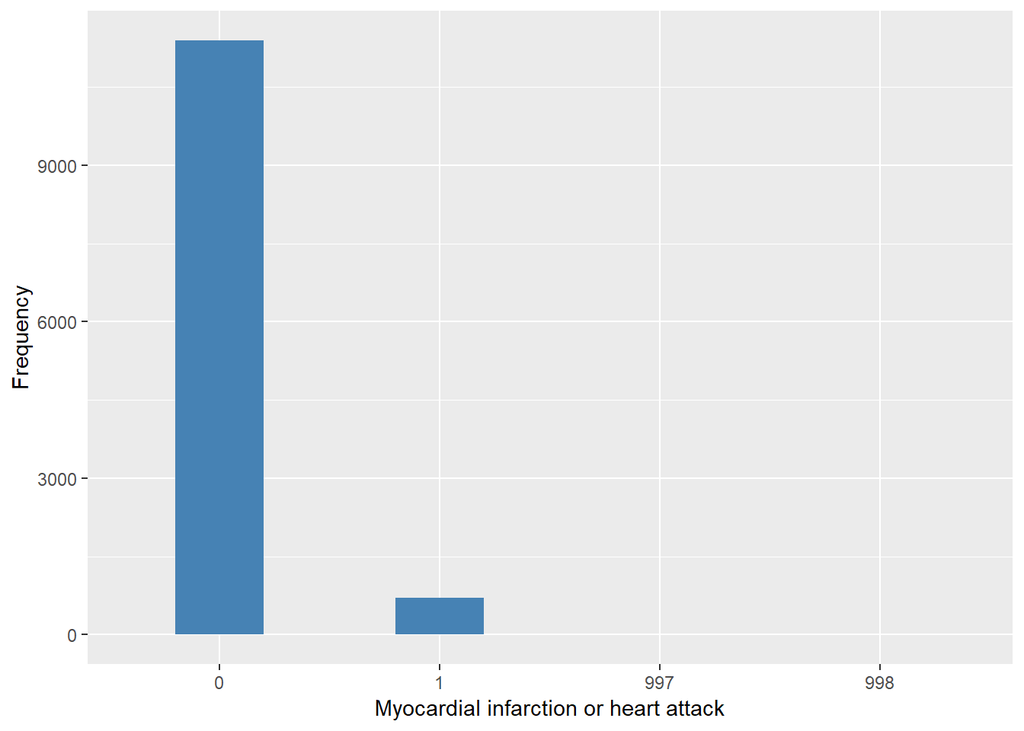

Age of each episode of myocardial infarction or heart attack

| Sample size | Missing values |
| --- | --- |
| 12099 | 11598 |

Values

|  | No-missings | 991 | 992 | 993 | 994 | 995 | 996 | 997 | 998 | 999 | NA |
| --- | --- | --- | --- | --- | --- | --- | --- | --- | --- | --- | --- |
| Frequency | 501.00 | 0 | 0 | 0 | 0 | 0 | 11587.00 | 1.00 | 1.00 | 9.00 | 0 |
| Percentage | 4.14 | 0 | 0 | 0 | 0 | 0 | 95.77 | 0.01 | 0.01 | 0.07 | 0 |

Summary

| Min. | 1st Qu. | Median | Mean | 3rd Qu. | Max. |
| --- | --- | --- | --- | --- | --- |
| 16 | 53 | 61 | 60.29 | 69 | 91 |

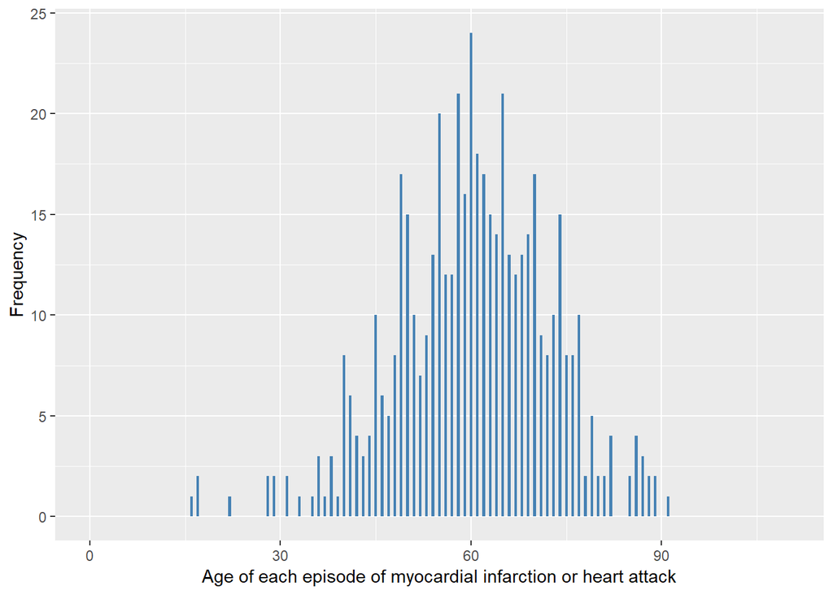

#### 2.1.1.4 Validation

|  | hedimX!=3->0 | hedimX==3->1 | hedimX==-9->997 | hedimX==-8->998 |
| --- | --- | --- | --- | --- |
| BeforeH | 11388 | 702 | 3 | 6 |
| AfterH | 11388 | 702 | 3 | 6 |

### 2.1.2 Wave 2

#### 2.1.2.1 Study-specific variable description

| **Name** | `hedim01` | `hedim02` | `hedim03` | `hedim04` | `hedim05` | `hedim06` | `hedim07` | `hedim08` | `hedia01` | `HeAgbRY` | `ybirth` |
| --- | --- | --- | --- | --- | --- | --- | --- | --- | --- | --- | --- |
| **Label** | `Diagnosed cardiovascular condit. newly reported at W2 (1st mention) (merged var)` | `Diagnosed cardiovascular condit. newly reported at W2 (2nd mention) (merged var)` | `Diagnosed cardiovascular condit. newly reported at W2 (3rd mention) (merged var)` | `Diagnosed cardiovascular condit. newly reported at W2 (4th mention) (merged var)` | `Diagnosed cardiovascular condit. newly reported at W2 (5th mention) (merged var)` | `Diagnosed cardiovascular condit. newly reported at W2 (6th mention) (merged var)` | `Diagnosed cardiovascular condit. newly reported at W2 (7th mention) (merged var)` | `Diagnosed cardiovascular condit. newly reported at W2 (8th mention) (merged var)` | `Diagnosed cardiovascular condition newly reported at W2 (1st mention)` | `Year told had heart attack in last 2 years` | `year of birth` |
| **Table name** | `wave_2_core_data_v4` | `wave_2_core_data_v4` | `wave_2_core_data_v4` | `wave_2_core_data_v4` | `wave_2_core_data_v4` | `wave_2_core_data_v4` | `wave_2_core_data_v4` | `wave_2_core_data_v4` | `wave_2_core_data_v4` | `wave_2_core_data_v4` | `elsa_w2_hd` |
| **Categories** | `1 = High blood pressure or hypertension` `2 = Angina` `3 = A heart attack (including myocardial infarction or coronary)` `4 = Congestive heart failure` `5 = A heart murmur` `6 = An abnormal heart rhy… | `1 = High blood pressure or hypertension` `2 = Angina` `3 = A heart attack (including myocardial infarction or coronary)` `4 = Congestive heart failure` `5 = A heart murmur` `6 = An abnormal heart rhy… | `1 = High blood pressure or hypertension` `2 = Angina` `3 = A heart attack (including myocardial infarction or coronary)` `4 = Congestive heart failure` `5 = A heart murmur` `6 = An abnormal heart rhy… | `1 = High blood pressure or hypertension` `2 = Angina` `3 = A heart attack (including myocardial infarction or coronary)` `4 = Congestive heart failure` `5 = A heart murmur` `6 = An abnormal heart rhy… | `1 = High blood pressure or hypertension` `2 = Angina` `3 = A heart attack (including myocardial infarction or coronary)` `4 = Congestive heart failure` `5 = A heart murmur` `6 = An abnormal heart rhy… | `1 = High blood pressure or hypertension` `2 = Angina` `3 = A heart attack (including myocardial infarction or coronary)` `4 = Congestive heart failure` `5 = A heart murmur` `6 = An abnormal heart rhy… | `1 = High blood pressure or hypertension` `2 = Angina` `3 = A heart attack (including myocardial infarction or coronary)` `4 = Congestive heart failure` `5 = A heart murmur` `6 = An abnormal heart rhy… | `1 = High blood pressure or hypertension` `2 = Angina` `3 = A heart attack (including myocardial infarction or coronary)` `4 = Congestive heart failure` `5 = A heart murmur` `6 = An abnormal heart rhy… | `1 = High blood pressure or hypertension` `2 = Angina` `3 = A heart attack (including myocardial infarction or coronary)` `4 = Congestive heart failure` `5 = A heart murmur` `6 = An abnormal heart rhy… | `continuous` | `continuous` |
| **Missings** | `-9 = Refusal` `-8 = Don't know` `-1 = Not applicable` | `-9 = Refusal` `-8 = Don't know` `-1 = Not applicable` | `-9 = Refusal` `-8 = Don't know` `-1 = Not applicable` | `-9 = Refusal` `-8 = Don't know` `-1 = Not applicable` | `-9 = Refusal` `-8 = Don't know` `-1 = Not applicable` | `-9 = Refusal` `-8 = Don't know` `-1 = Not applicable` | `-9 = Refusal` `-8 = Don't know` `-1 = Not applicable` | `-9 = Refusal` `-8 = Don't know` `-1 = Not applicable` | `-9 = Refusal` `-8 = Don't know` `-1 = Not applicable` | `-9 = Refusal` `-8 = Don't know` `-1 = Not applicable` |  |
| **Description** |  |  |  |  |  |  |  |  |  |  |  |

hedim01

| Sample size | Missing values |
| --- | --- |
| 9432 | 9 |

Category

|  | 1 | 2 | 3 | 4 | 5 | 6 | 7 | 8 | 9 | 51 | 52 | 85 | 86 | 96 |
| --- | --- | --- | --- | --- | --- | --- | --- | --- | --- | --- | --- | --- | --- | --- |
| Frequency | 1707.0 | 213.00 | 59.00 | 14.00 | 91.00 | 196.00 | 171.00 | 76.00 | 946.00 | 6.00 | 7.00 | 27.00 | 8.00 | 5902.00 |
| Percentage | 18.1 | 2.26 | 0.63 | 0.15 | 0.96 | 2.08 | 1.81 | 0.81 | 10.03 | 0.06 | 0.07 | 0.29 | 0.08 | 62.57 |

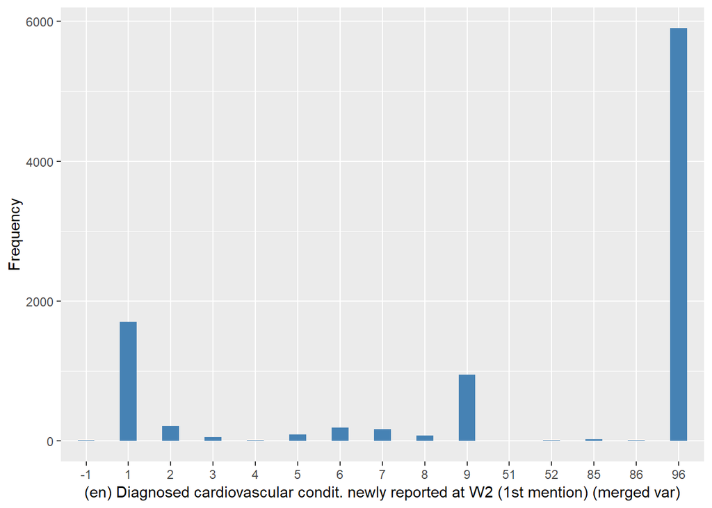

hedim02

| Sample size | Missing values |
| --- | --- |
| 9432 | 8262 |

Category

|  | 2 | 3 | 4 | 5 | 6 | 7 | 8 | 9 | 51 | 52 | 85 | 86 |
| --- | --- | --- | --- | --- | --- | --- | --- | --- | --- | --- | --- | --- |
| Frequency | 148.00 | 51.00 | 7.00 | 59.00 | 110.00 | 151.0 | 63.00 | 546.00 | 8.00 | 4.00 | 18.00 | 5.00 |
| Percentage | 1.57 | 0.54 | 0.07 | 0.63 | 1.17 | 1.6 | 0.67 | 5.79 | 0.08 | 0.04 | 0.19 | 0.05 |

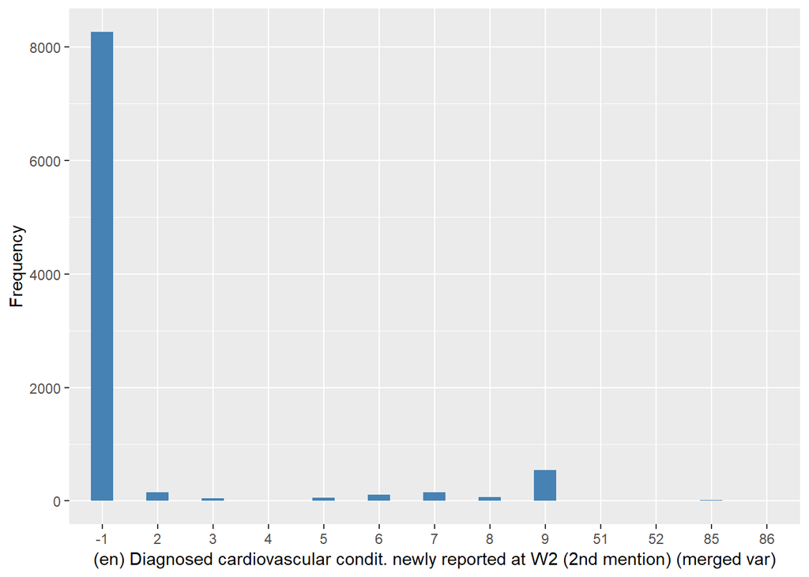

hedim03

| Sample size | Missing values |
| --- | --- |
| 9432 | 9078 |

Category

|  | 3 | 4 | 5 | 6 | 7 | 8 | 9 | 51 | 52 | 85 |
| --- | --- | --- | --- | --- | --- | --- | --- | --- | --- | --- |
| Frequency | 22.00 | 3.00 | 17.00 | 31.00 | 54.00 | 24.00 | 175.00 | 8.00 | 7.00 | 13.00 |
| Percentage | 0.23 | 0.03 | 0.18 | 0.33 | 0.57 | 0.25 | 1.86 | 0.08 | 0.07 | 0.14 |

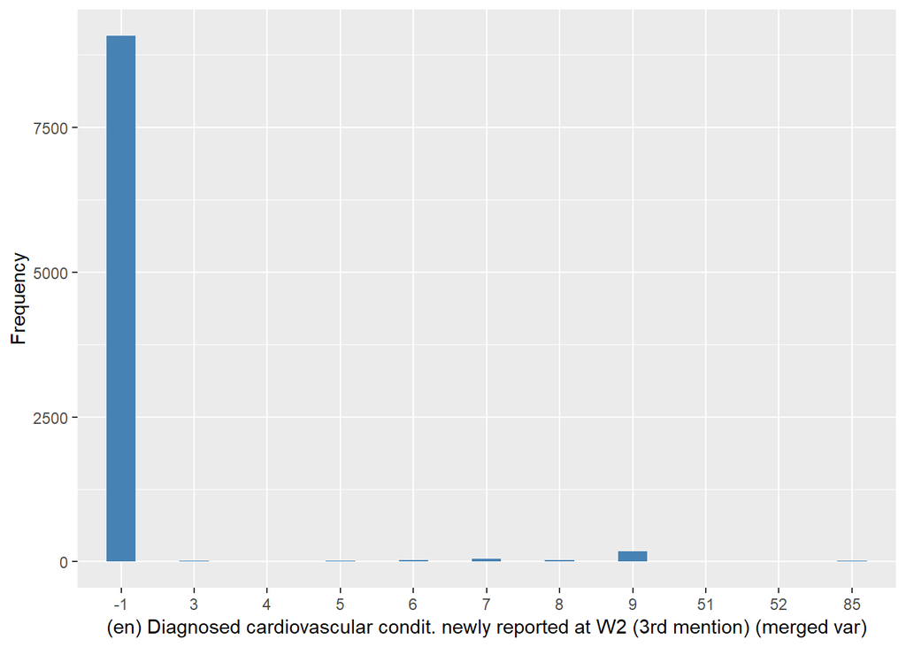

hedim04

| Sample size | Missing values |
| --- | --- |
| 9432 | 9336 |

Category

|  | 4 | 5 | 6 | 7 | 8 | 9 | 51 | 52 | 85 |
| --- | --- | --- | --- | --- | --- | --- | --- | --- | --- |
| Frequency | 2.00 | 3.00 | 3.00 | 8.00 | 6.00 | 60.00 | 7.00 | 4.00 | 3.00 |
| Percentage | 0.02 | 0.03 | 0.03 | 0.08 | 0.06 | 0.64 | 0.07 | 0.04 | 0.03 |

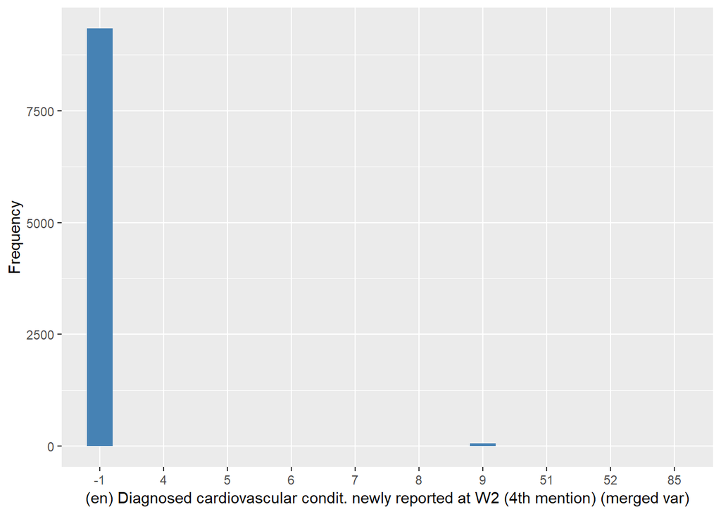

hedim05

| Sample size | Missing values |
| --- | --- |
| 9432 | 9414 |

Category

|  | 6 | 8 | 9 | 51 | 52 | 85 |
| --- | --- | --- | --- | --- | --- | --- |
| Frequency | 3.00 | 1.00 | 10.00 | 2.00 | 1.00 | 1.00 |
| Percentage | 0.03 | 0.01 | 0.11 | 0.02 | 0.01 | 0.01 |

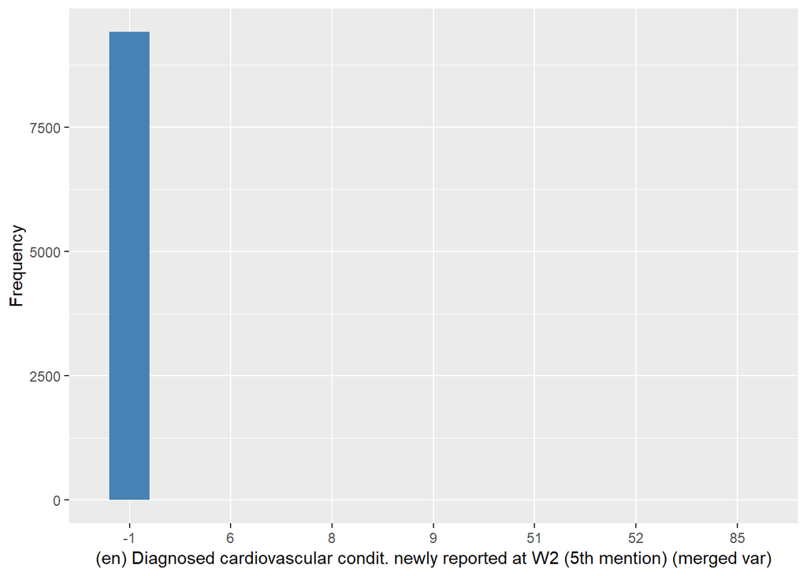

hedim06

| Sample size | Missing values |
| --- | --- |
| 9432 | 9427 |

Category

|  | 7 | 9 | 52 |
| --- | --- | --- | --- |
| Frequency | 1.00 | 3.00 | 1.00 |
| Percentage | 0.01 | 0.03 | 0.01 |

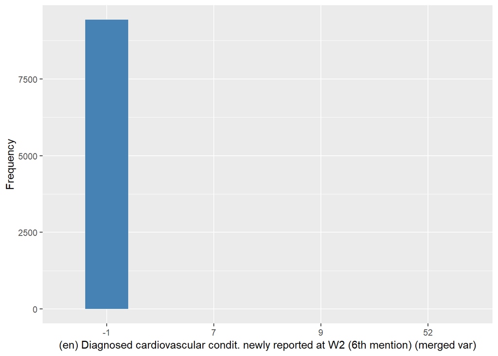

hedim07

| Sample size | Missing values |
| --- | --- |
| 9432 | 9431 |

Category

|  | 9 |
| --- | --- |
| Frequency | 1.00 |
| Percentage | 0.01 |

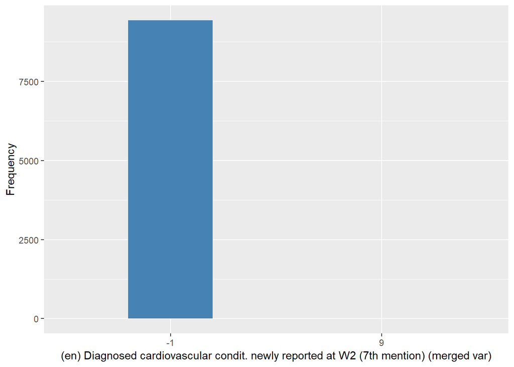

hedim08

| Sample size | Missing values |
| --- | --- |
| 9432 | 9431 |

Category

|  | 52 |
| --- | --- |
| Frequency | 1.00 |
| Percentage | 0.01 |

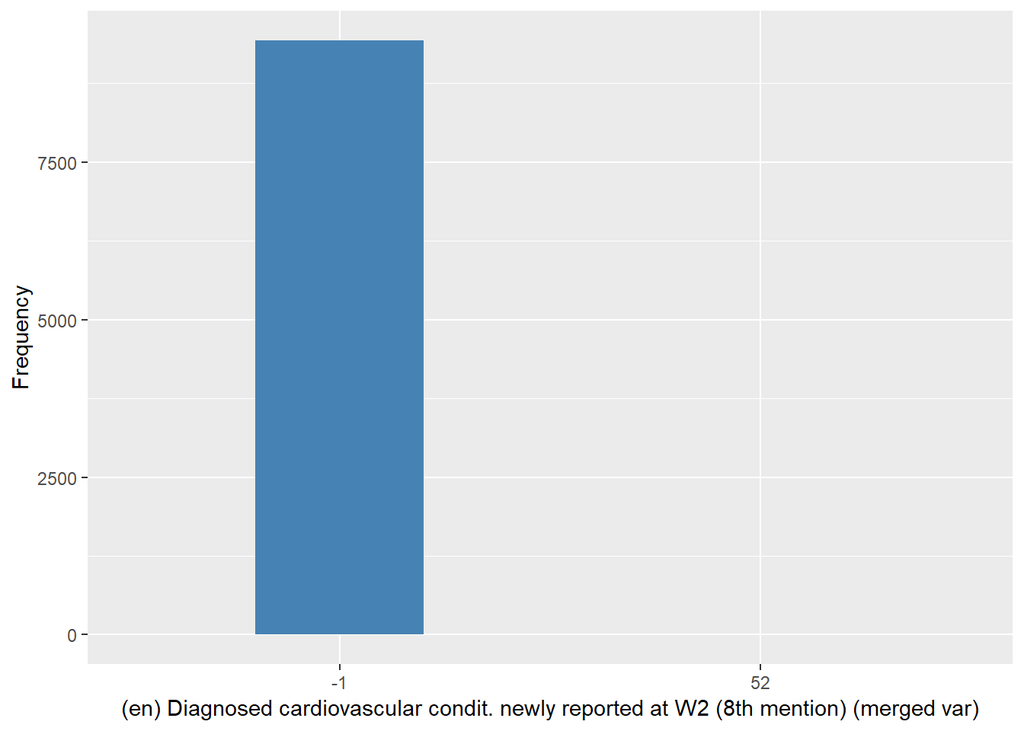

hedia01

| Sample size | Missing values |
| --- | --- |
| 9432 | 9 |

Category

|  | 1 | 2 | 3 | 4 | 5 | 6 | 7 | 8 | 9 | 95 | 96 |
| --- | --- | --- | --- | --- | --- | --- | --- | --- | --- | --- | --- |
| Frequency | 1634.00 | 204.00 | 64.00 | 11.00 | 81.00 | 175.00 | 178.00 | 86.00 | 997.00 | 91.00 | 5902.00 |
| Percentage | 17.32 | 2.16 | 0.68 | 0.12 | 0.86 | 1.86 | 1.89 | 0.91 | 10.57 | 0.96 | 62.57 |

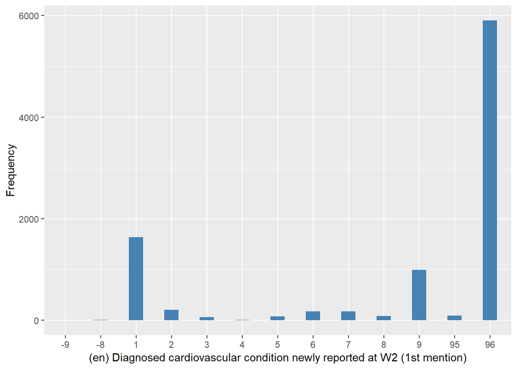

HeAgbRY

| Sample size | Missing values |
| --- | --- |
| 9432 | 9318 |

Category

|  | 2002 | 2003 | 2004 |
| --- | --- | --- | --- |
| Frequency | 23.00 | 44.00 | 47.0 |
| Percentage | 0.24 | 0.47 | 0.5 |

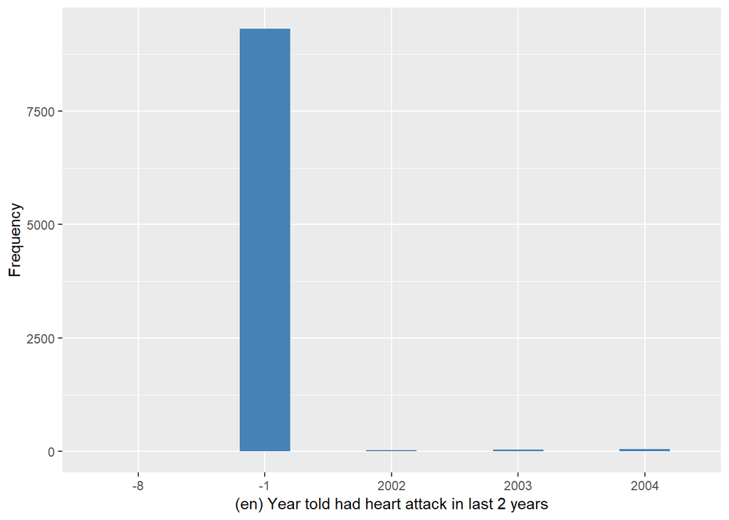

ybirth

| Sample size | Missing values |
| --- | --- |
| 9432 | 0 |

Summary

| Min. | 1st Qu. | Median | Mean | 3rd Qu. | Max. |
| --- | --- | --- | --- | --- | --- |
| 1908 | 1931 | 1939 | 1938 | 1947 | 1987 |

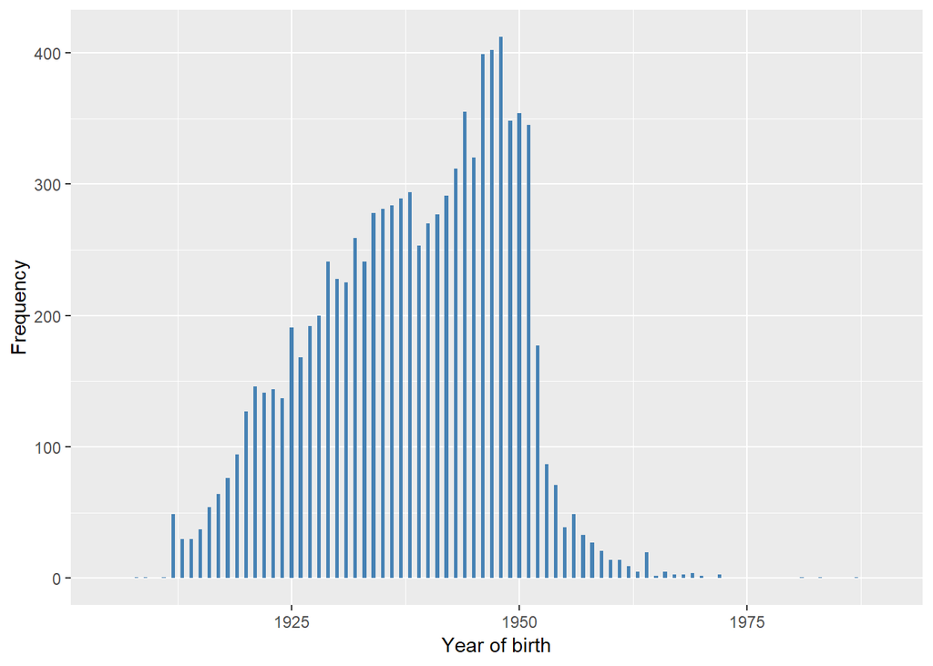

#### 2.1.2.2 Harmonisation algorithm

To compute `mi_ha` from the study-specific variable it has to be recoded as follows:

- `some hedimX == 3 into 1`
- `hedia01 == -9 and hedimX == -1 into 997`
- `hedia01 == -8 and hedimX == -1 into 998`
- `otherwise into 0`

To compute `mi_ha_age` from the study-specific variable it has to be recoded as follows:

- `if mi_ha == 1, mi_ha_age = HeAgbRY - ybirth`
- `if mi_ha == 0, mi_ha_age = 996`
- `-9 into 997`
- `-8 into 998`
- `-1 into 996`
- `otherwise, mi_ha_age = 999`

**R script:**

```r
# Categorical variable harmonization
ELSA_ds_w2 <- tibble(id = ELSA_w2$id)
ELSA_ds_w2$mi_ha <- rep(0, length(ELSA_w2$id))
ELSA_ds_w2$mi_ha[which(ELSA_w2$hedim01 == 3 | ELSA_w2$hedim02 == 3 | ELSA_w2$hedim03 ==
    3 | ELSA_w2$hedim04 == 3 | ELSA_w2$hedim05 == 3 | ELSA_w2$hedim06 == 3 |
    ELSA_w2$hedim07 == 3 | ELSA_w2$hedim08 == 3)] <- 1
ELSA_ds_w2$mi_ha[which(ELSA_w2$hedia01 == -9 & ELSA_w2$hedim01 == -1)] <- 997
ELSA_ds_w2$mi_ha[which(ELSA_w2$hedia01 == -8 & ELSA_w2$hedim01 == -1)] <- 998

# Continuous variable harmonization
ELSA_ds_w2$mi_ha_age <- rep(999, length(ELSA_w2$id))
ELSA_ds_w2$mi_ha_age[which(ELSA_ds_w2$mi_ha == 0)] <- 996
ELSA_ds_w2$mi_ha_age[which(ELSA_ds_w2$mi_ha == 1 & !ELSA_w2$HeAgbRY %in% c(-1,
    -8, -9))] <- ELSA_w2$HeAgbRY[which(ELSA_ds_w2$mi_ha == 1 & !ELSA_w2$HeAgbRY %in%
    c(-1, -8, -9))] - ELSA_w2$ybirth[which(ELSA_ds_w2$mi_ha == 1 & !ELSA_w2$HeAgbRY %in%
    c(-1, -8, -9))]
ELSA_ds_w2$mi_ha_age <- car::recode(ELSA_ds_w2$mi_ha_age, "-1=996;-8=998;-9=997;NA=999")
```

#### 2.1.2.3 Statistics of the new harmonized variable

Myocardial infarction or heart attack

| Sample size | Missing values |
| --- | --- |
| 9432 | 9 |

Category

|  | 0 | 1 |
| --- | --- | --- |
| Frequency | 9291.00 | 132.0 |
| Percentage | 98.51 | 1.4 |

Type of missing

|  | 991 | 992 | 993 | 994 | 995 | 996 | 997 | 998 | 999 | NA |
| --- | --- | --- | --- | --- | --- | --- | --- | --- | --- | --- |
| Frequency | 0 | 0 | 0 | 0 | 0 | 0 | 1.00 | 8.00 | 0 | 0 |
| Percentage | 0 | 0 | 0 | 0 | 0 | 0 | 0.01 | 0.08 | 0 | 0 |

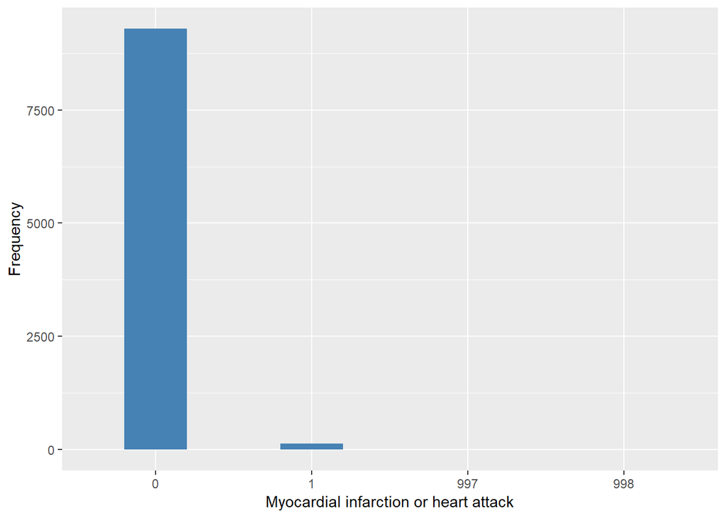

Age of each episode of myocardial infarction or heart attack

| Sample size | Missing values |
| --- | --- |
| 9432 | 9318 |

Values

|  | No-missings | 991 | 992 | 993 | 994 | 995 | 996 | 997 | 998 | 999 | NA |
| --- | --- | --- | --- | --- | --- | --- | --- | --- | --- | --- | --- |
| Frequency | 114.00 | 0 | 0 | 0 | 0 | 0 | 9291.00 | 0 | 0 | 27.00 | 0 |
| Percentage | 1.21 | 0 | 0 | 0 | 0 | 0 | 98.51 | 0 | 0 | 0.29 | 0 |

Summary

| Min. | 1st Qu. | Median | Mean | 3rd Qu. | Max. |
| --- | --- | --- | --- | --- | --- |
| 52 | 61 | 68.5 | 69.68 | 78 | 91 |

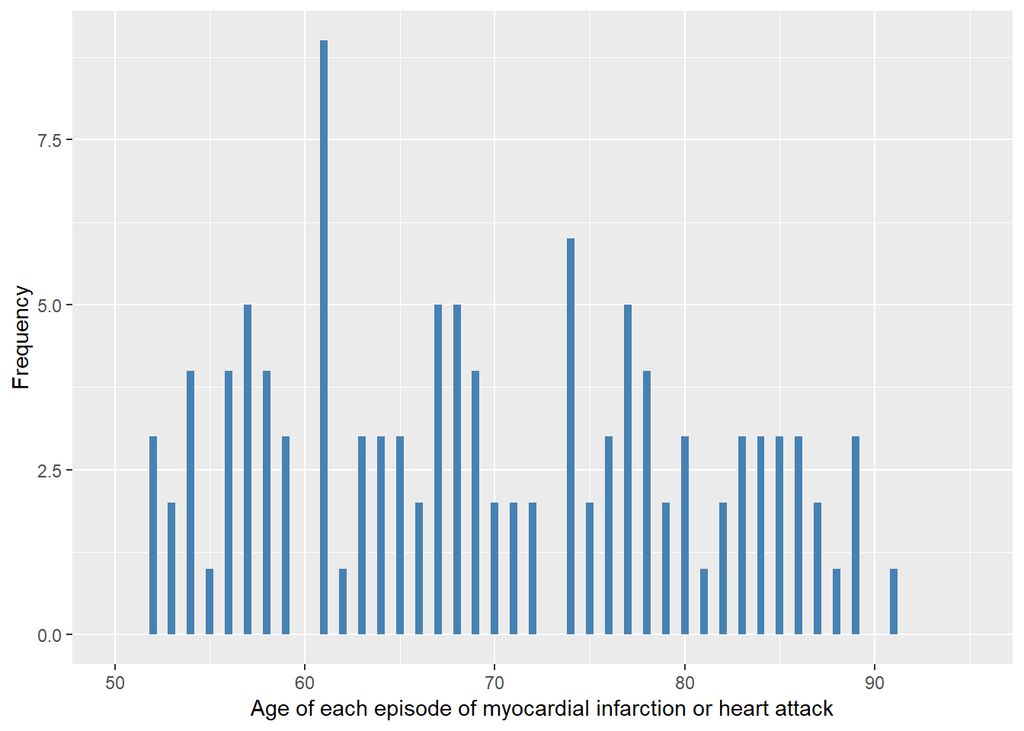

#### 2.1.2.4 Validation

|  | hedimX!=3->0 | hedimX==3->1 | hedimX==-9->997 | hedimX==-8->998 |
| --- | --- | --- | --- | --- |
| BeforeH | 9291 | 132 | 1 | 8 |
| AfterH | 9291 | 132 | 1 | 8 |

### 2.1.3 Wave 3

#### 2.1.3.1 Study-specific variable description

| **Name** | `dhedimmi` | `ybirth` | `heagbry` |
| --- | --- | --- | --- |
| **Label** | `CVD: heart attack diagnosis newly reported (merged)` | `year of birth` | `Year told had heart attack in last 2 years` |
| **Table name** | `wave_3_elsa_data_v4` | `elsa_w3_hd` | `wave_3_elsa_data_v4` |
| **Categories** | `1 = Mentioned` `0 = Not mentioned` | `continuous` | `continuous` |
| **Missings** | `-9 = Refusal` `-8 = Don't know` `-1 = Not applicable` | `998 = Do not know` | `-9 = Refusal` `-8 = Don't know` `-1 = Not applicable` |
| **Description** |  |  |  |

dhedimmi

| Sample size | Missing values |
| --- | --- |
| 9771 | 5 |

Category

|  | 0 | 1 |
| --- | --- | --- |
| Frequency | 9655.00 | 111.00 |
| Percentage | 98.81 | 1.14 |

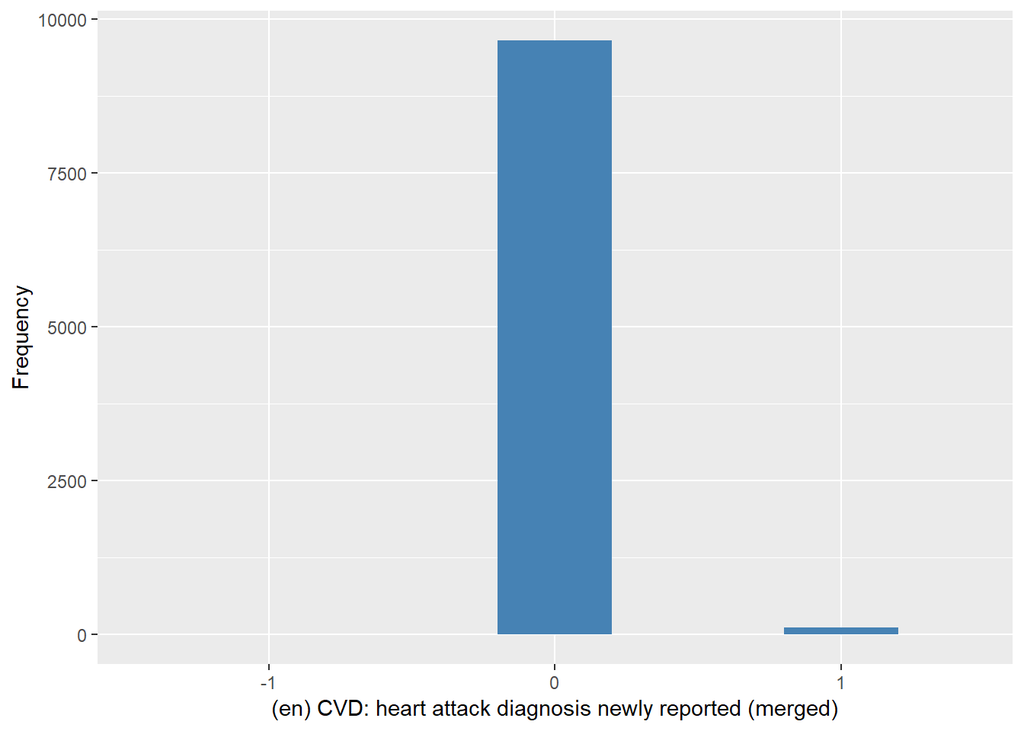

ybirth

| Sample size | Missing values |
| --- | --- |
| 9771 | 1 |

Summary

| Min. | 1st Qu. | Median | Mean | 3rd Qu. | Max. |
| --- | --- | --- | --- | --- | --- |
| 1908 | 1933 | 1943 | 1941 | 1950 | 1987 |

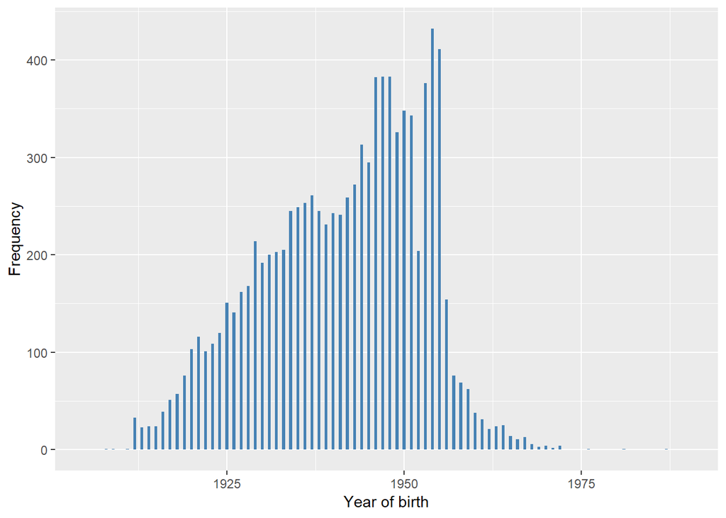

heagbry

| Sample size | Missing values |
| --- | --- |
| 9771 | 9703 |

Summary

| Min. | 1st Qu. | Median | Mean | 3rd Qu. | Max. |
| --- | --- | --- | --- | --- | --- |
| 1984 | 2005 | 2005 | 2004 | 2006 | 2006 |

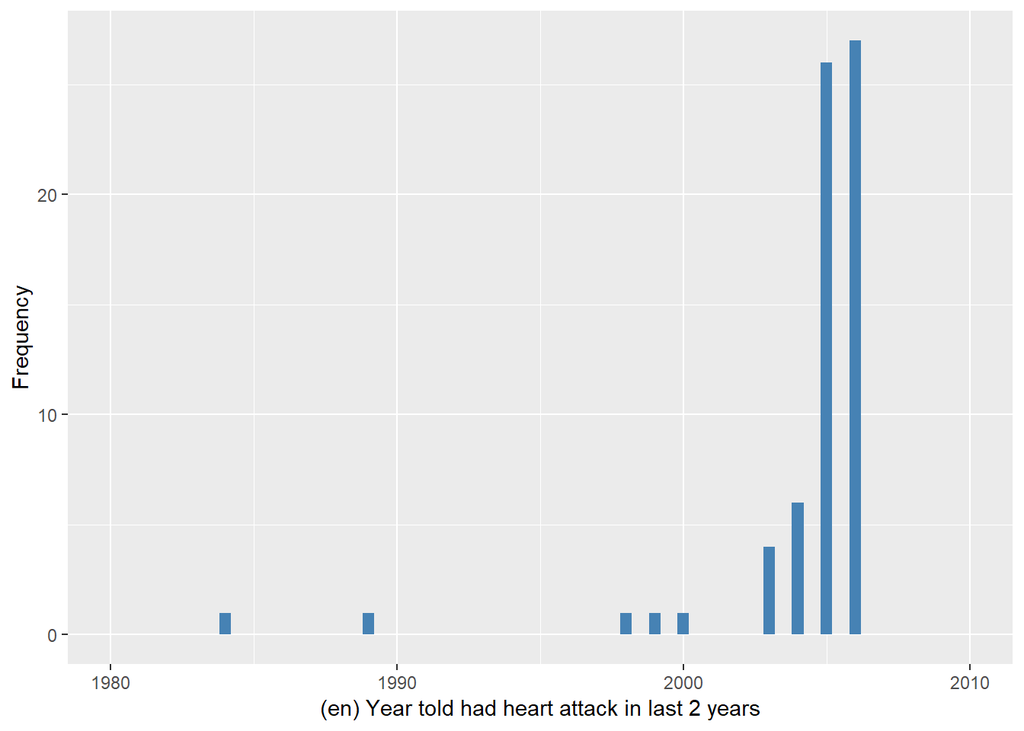

#### 2.1.3.2 Harmonisation algorithm

To compute `mi_ha` from the study-specific variable it has to be recoded as follows:

- `dhedimmi == 1 into 1`
- `dhedimmi == 0 into 0`
- `dhedimmi == -1 into 996`

To compute `mi_ha_age` from the study-specific variable it has to be recoded as follows:

- `if mi_ha == 1, mi_ha_age = heagbry - ybirth`
- `if mi_ha == 0, mi_ha_age = 996`
- `-9 into 997`
- `-8 into 998`
- `-1 into 996`
- `otherwise, mi_ha_age = 999`

**R script:**

```r
# Categorical variable harmonization
ELSA_ds_w3 <- tibble(id = ELSA_w3$id)
ELSA_ds_w3$mi_ha <- car::recode(ELSA_w3$dhedimmi, "-1=996")

# Continuous variable harmonization
ELSA_ds_w3$mi_ha_age <- rep(999, length(ELSA_w3$id))
ELSA_ds_w3$mi_ha_age[which(ELSA_ds_w3$mi_ha == 0)] <- 996
ELSA_ds_w3$mi_ha_age[which(ELSA_ds_w3$mi_ha == 1 & !ELSA_w3$heagbry %in% c(-1,
    -8, -9) & ELSA_w3$ybirth != 998)] <- ELSA_w3$heagbry[which(ELSA_ds_w3$mi_ha ==
    1 & !ELSA_w3$heagbry %in% c(-1, -8, -9) & ELSA_w3$ybirth != 998)] - ELSA_w3$ybirth[which(ELSA_ds_w3$mi_ha ==
    1 & !ELSA_w3$heagbry %in% c(-1, -8, -9) & ELSA_w3$ybirth != 998)]
ELSA_ds_w3$mi_ha_age <- car::recode(ELSA_ds_w3$mi_ha_age, "-1=996;-8=998;-9=997;NA=999")
```

#### 2.1.3.3 Statistics of the new harmonized variable

Myocardial infarction or heart attack

| Sample size | Missing values |
| --- | --- |
| 9771 | 5 |

Category

|  | 0 | 1 |
| --- | --- | --- |
| Frequency | 9655.00 | 111.00 |
| Percentage | 98.81 | 1.14 |

Type of missing

|  | 991 | 992 | 993 | 994 | 995 | 996 | 997 | 998 | 999 | NA |
| --- | --- | --- | --- | --- | --- | --- | --- | --- | --- | --- |
| Frequency | 0 | 0 | 0 | 0 | 0 | 5.00 | 0 | 0 | 0 | 0 |
| Percentage | 0 | 0 | 0 | 0 | 0 | 0.05 | 0 | 0 | 0 | 0 |

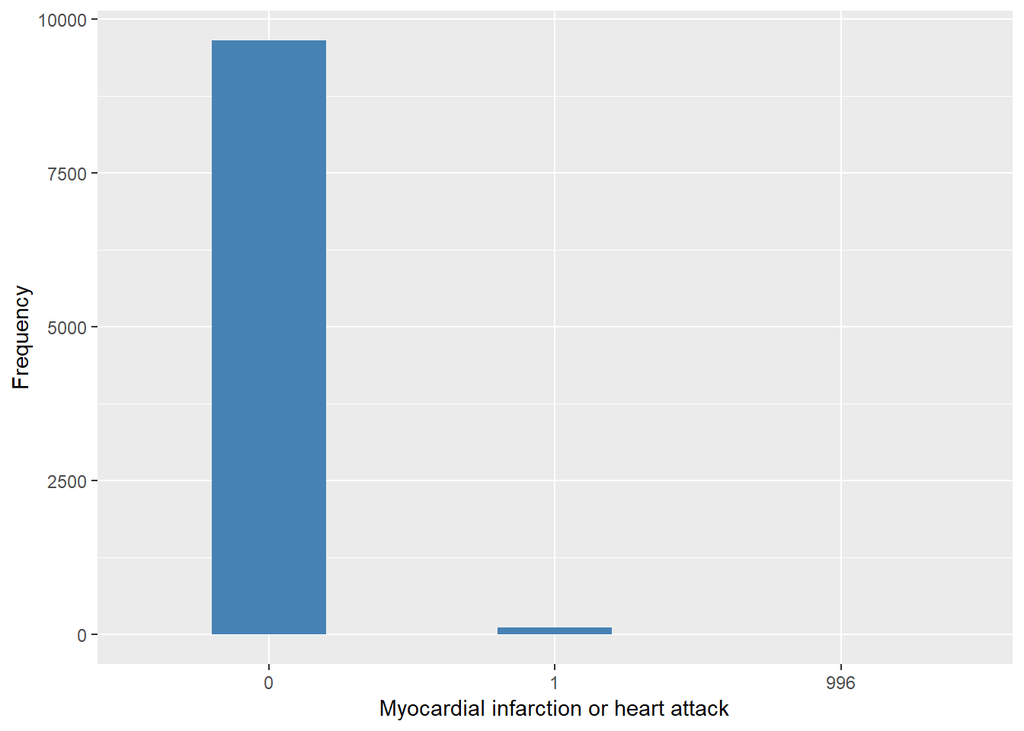

Age of each episode of myocardial infarction or heart attack

| Sample size | Missing values |
| --- | --- |
| 9771 | 9703 |

Values

|  | No-missings | 991 | 992 | 993 | 994 | 995 | 996 | 997 | 998 | 999 | NA |
| --- | --- | --- | --- | --- | --- | --- | --- | --- | --- | --- | --- |
| Frequency | 68.0 | 0 | 0 | 0 | 0 | 0 | 9655.00 | 0 | 0 | 48.00 | 0 |
| Percentage | 0.7 | 0 | 0 | 0 | 0 | 0 | 98.81 | 0 | 0 | 0.49 | 0 |

Summary

| Min. | 1st Qu. | Median | Mean | 3rd Qu. | Max. |
| --- | --- | --- | --- | --- | --- |
| 42 | 62.75 | 71 | 70.54 | 77 | 92 |

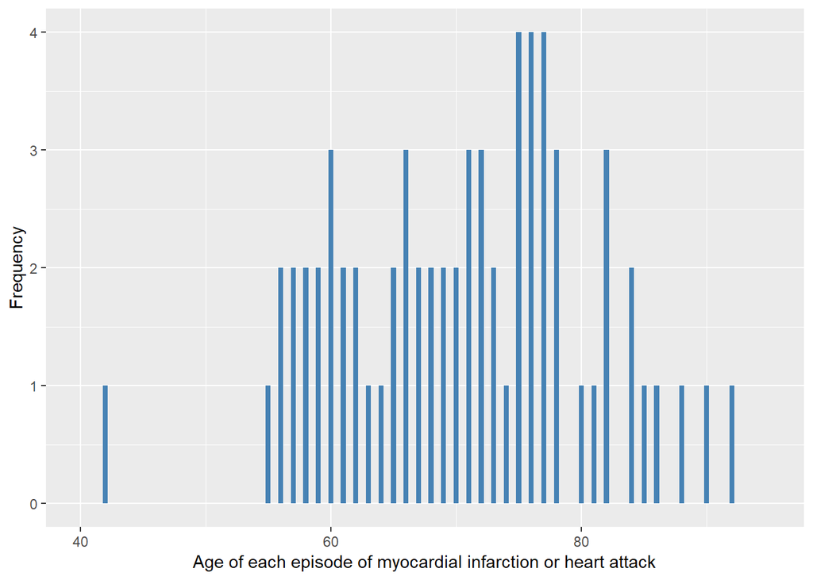

#### 2.1.3.4 Validation

|  | dhedimmi==0->0 | dhedimmi==1->1 | dhedimmi==-1->996 |
| --- | --- | --- | --- |
| BeforeH | 9655 | 111 | 5 |
| AfterH | 9655 | 111 | 5 |

### 2.1.4 Wave 4

#### 2.1.4.1 Study-specific variable description

| **Name** | `hedimmi` | `ybirth` | `heagbry` |
| --- | --- | --- | --- |
| **Label** | `CVD: heart attack diagnosis newly reported (merged)` | `year of birth` | `Year told had heart attack in last 2 years` |
| **Table name** | `wave_4_elsa_data_v3` | `elsa_w4_hd` | `wave_4_elsa_data_v3` |
| **Categories** | `1 = Mentioned` `0 = Not mentioned` | `continuous` | `continuous` |
| **Missings** | `-9 = Refusal` `-8 = Don't know` `-1 = Not applicable` |  | `-9 = Refusal` `-8 = Don't know` `-2 = Capi/Interview Error` `-1 = Not applicable` |
| **Description** |  |  |  |

hedimmi

| Sample size | Missing values |
| --- | --- |
| 11050 | 16 |

Category

|  | 0 | 1 |
| --- | --- | --- |
| Frequency | 10894.00 | 140.00 |
| Percentage | 98.59 | 1.27 |

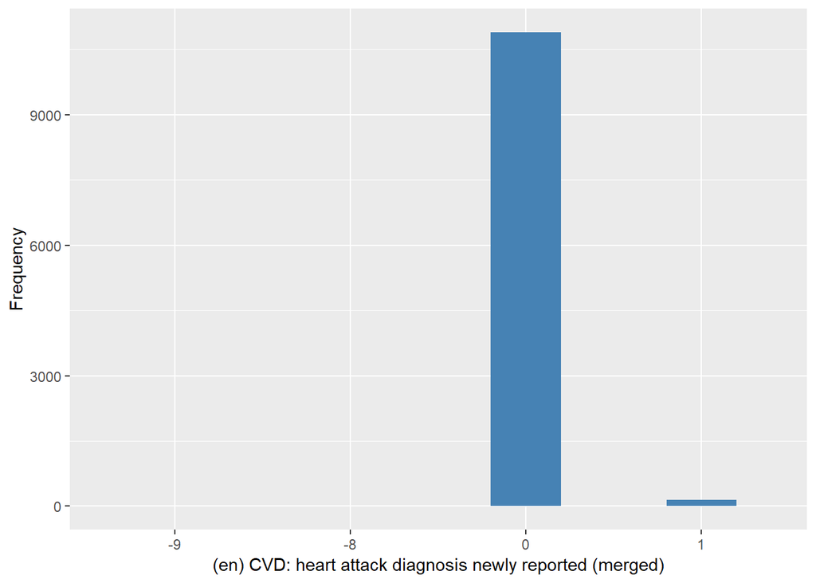

heagbry

| Sample size | Missing values |
| --- | --- |
| 11050 | 10990 |

Summary

| Min. | 1st Qu. | Median | Mean | 3rd Qu. | Max. |
| --- | --- | --- | --- | --- | --- |
| 1976 | 2007 | 2007 | 2006 | 2008 | 2008 |

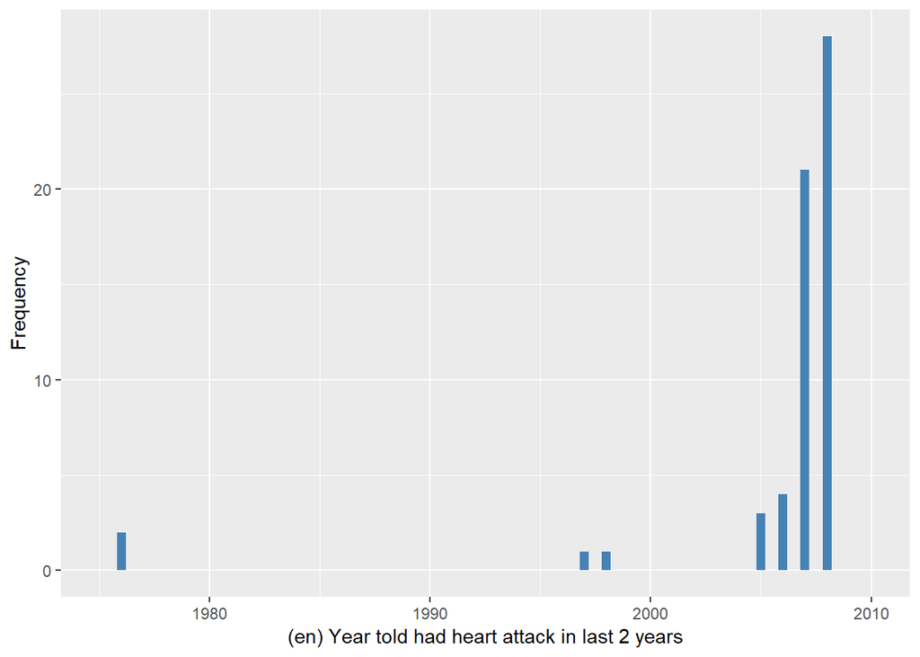

ybirth

| Sample size | Missing values |
| --- | --- |
| 11050 | 0 |

Summary

| Min. | 1st Qu. | Median | Mean | 3rd Qu. | Max. |
| --- | --- | --- | --- | --- | --- |
| 1908 | 1936 | 1944 | 1943 | 1951 | 1984 |

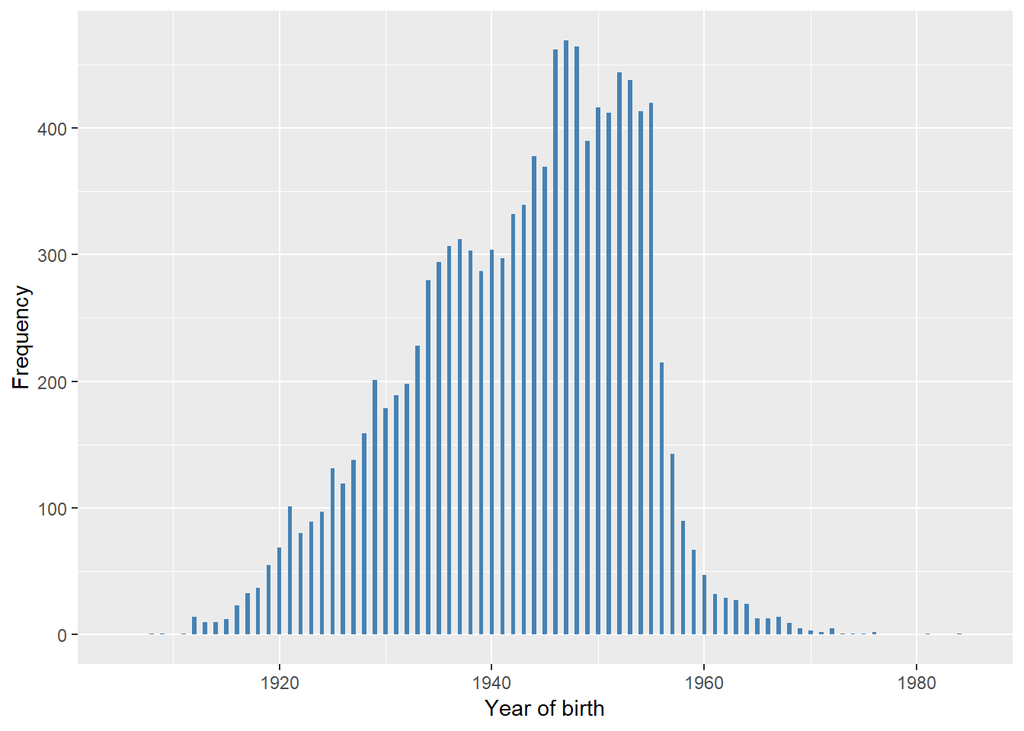

#### 2.1.4.2 Harmonisation algorithm

To compute `mi_ha` from the study-specific variable it has to be recoded as follows:

- `hedimmi == 1 into 1`
- `hedimmi == -9 into 997`
- `hedimmi == -8 into 998`
- `hedimmi == 0 into 0`

To compute `mi_ha_age` from the study-specific variable it has to be recoded as follows:

- `if mi_ha == 1, mi_ha_age = heagbry-ybirth`
- `if mi_ha == 0, mi_ha_age = 996`
- `-9 into 997`
- `-8 into 998`
- `-2 into 991`
- `-1 into 996`
- `otherwise, mi_ha_age = 999`

**R script:**

```r
# Categorical variable harmonization
ELSA_ds_w4 <- tibble(id = ELSA_w4$id)
ELSA_ds_w4$mi_ha <- car::recode(ELSA_w4$hedimmi, "-8=998;-9=997")

# Continuous variable harmonization
ELSA_ds_w4$mi_ha_age <- rep(999, length(ELSA_w4$id))
ELSA_ds_w4$mi_ha_age[which(ELSA_ds_w4$mi_ha == 0)] <- 996
ELSA_ds_w4$mi_ha_age[which(ELSA_ds_w4$mi_ha == 1 & !ELSA_w4$heagbry %in% c(-1,
    -8, -9, -2))] <- ELSA_w4$heagbry[which(ELSA_ds_w4$mi_ha == 1 & !ELSA_w4$heagbry %in%
    c(-1, -8, -9, -2))] - ELSA_w4$ybirth[which(ELSA_ds_w4$mi_ha == 1 & !ELSA_w4$heagbry %in%
    c(-1, -8, -9, -2))]
ELSA_ds_w4$mi_ha_age <- car::recode(ELSA_ds_w4$mi_ha_age, "-1=996;-8=998;-9=997;-2=991;NA=999")
```

#### 2.1.4.3 Statistics of the new harmonized variable

Myocardial infarction or heart attack

| Sample size | Missing values |
| --- | --- |
| 11050 | 16 |

Category

|  | 0 | 1 |
| --- | --- | --- |
| Frequency | 10894.00 | 140.00 |
| Percentage | 98.59 | 1.27 |

Type of missing

|  | 991 | 992 | 993 | 994 | 995 | 996 | 997 | 998 | 999 | NA |
| --- | --- | --- | --- | --- | --- | --- | --- | --- | --- | --- |
| Frequency | 0 | 0 | 0 | 0 | 0 | 0 | 7.00 | 9.00 | 0 | 0 |
| Percentage | 0 | 0 | 0 | 0 | 0 | 0 | 0.06 | 0.08 | 0 | 0 |

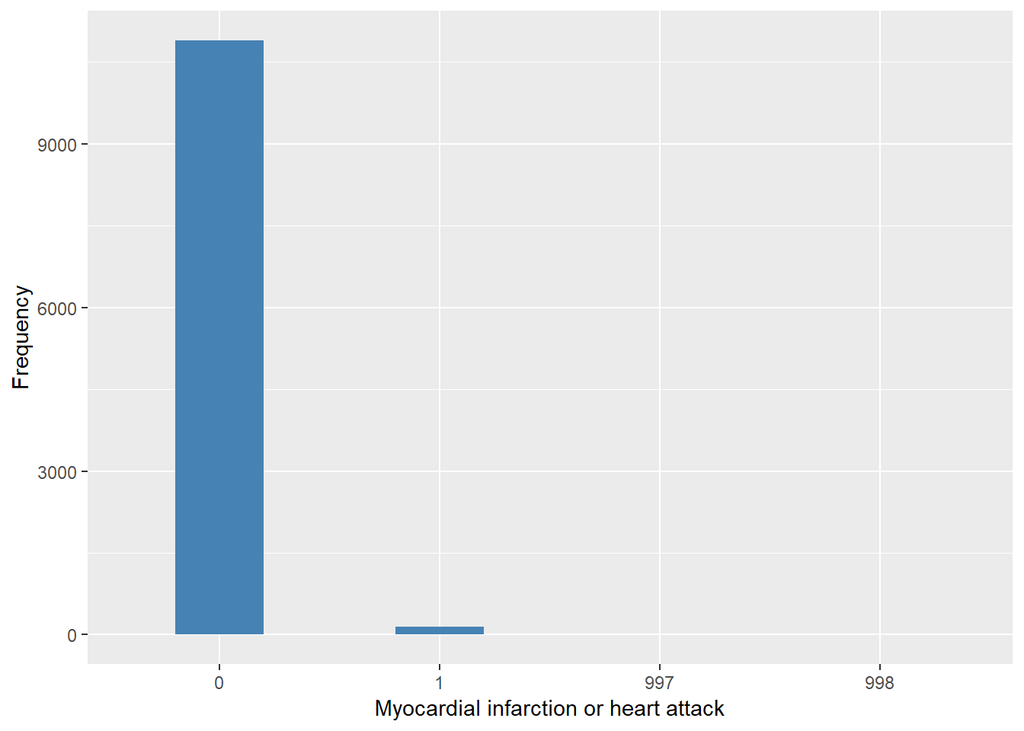

Age of each episode of myocardial infarction or heart attack

| Sample size | Missing values |
| --- | --- |
| 11050 | 10990 |

Values

|  | No-missings | 991 | 992 | 993 | 994 | 995 | 996 | 997 | 998 | 999 | NA |
| --- | --- | --- | --- | --- | --- | --- | --- | --- | --- | --- | --- |
| Frequency | 60.00 | 0 | 0 | 0 | 0 | 0 | 10894.00 | 0 | 0 | 96.00 | 0 |
| Percentage | 0.54 | 0 | 0 | 0 | 0 | 0 | 98.59 | 0 | 0 | 0.87 | 0 |

Summary

| Min. | 1st Qu. | Median | Mean | 3rd Qu. | Max. |
| --- | --- | --- | --- | --- | --- |
| 28 | 63.75 | 75.5 | 72.17 | 81.25 | 95 |

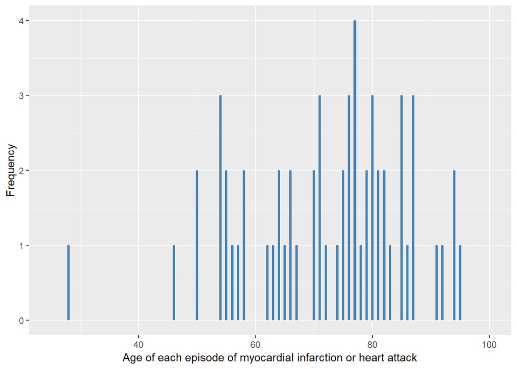

#### 2.1.4.4 Validation

|  | hedimmi==0->0 | hedimmi==1->1 | hedimmi==-9->997 | hedimmi==-8->998 |
| --- | --- | --- | --- | --- |
| BeforeH | 10894 | 140 | 7 | 9 |
| AfterH | 10894 | 140 | 7 | 9 |

### 2.1.5 Wave 5

#### 2.1.5.1 Study-specific variable description

| **Name** | `hedimmi` | `ybirth` | `heagbry` |
| --- | --- | --- | --- |
| **Label** | `CVD: heart attack diagnosis newly reported (merged)` | `year of birth` | `Year told had heart attack since last interview` |
| **Table name** | `wave_5_elsa_data_v4` | `elsa_w5_hd` | `wave_5_elsa_data_v4` |
| **Categories** | `1 = Mentioned` `0 = Not mentioned` | `continuous` | `continuous` |
| **Missings** | `-9 = Refusal` `-8 = Don't know` `-1 = Not applicable` |  | `-9 = Refusal` `-8 = Don't know` `-1 = Not applicable` |
| **Description** |  |  |  |

hedimmi

| Sample size | Missing values |
| --- | --- |
| 10274 | 15 |

Category

|  | 0 | 1 |
| --- | --- | --- |
| Frequency | 10137.00 | 122.00 |
| Percentage | 98.67 | 1.19 |

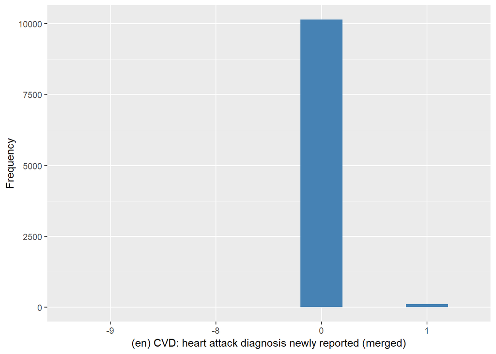

heagbry

| Sample size | Missing values |
| --- | --- |
| 10274 | 10199 |

Summary

| Min. | 1st Qu. | Median | Mean | 3rd Qu. | Max. |
| --- | --- | --- | --- | --- | --- |
| 1985 | 2009 | 2009 | 2008 | 2010 | 2011 |

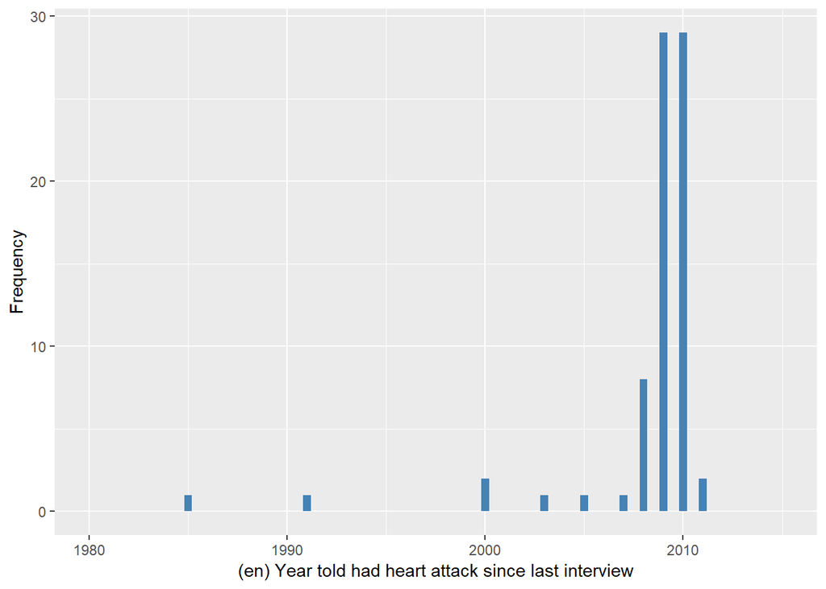

ybirth

| Sample size | Missing values |
| --- | --- |
| 10274 | 0 |

Summary

| Min. | 1st Qu. | Median | Mean | 3rd Qu. | Max. |
| --- | --- | --- | --- | --- | --- |
| 1908 | 1936 | 1945 | 1943 | 1951 | 1984 |

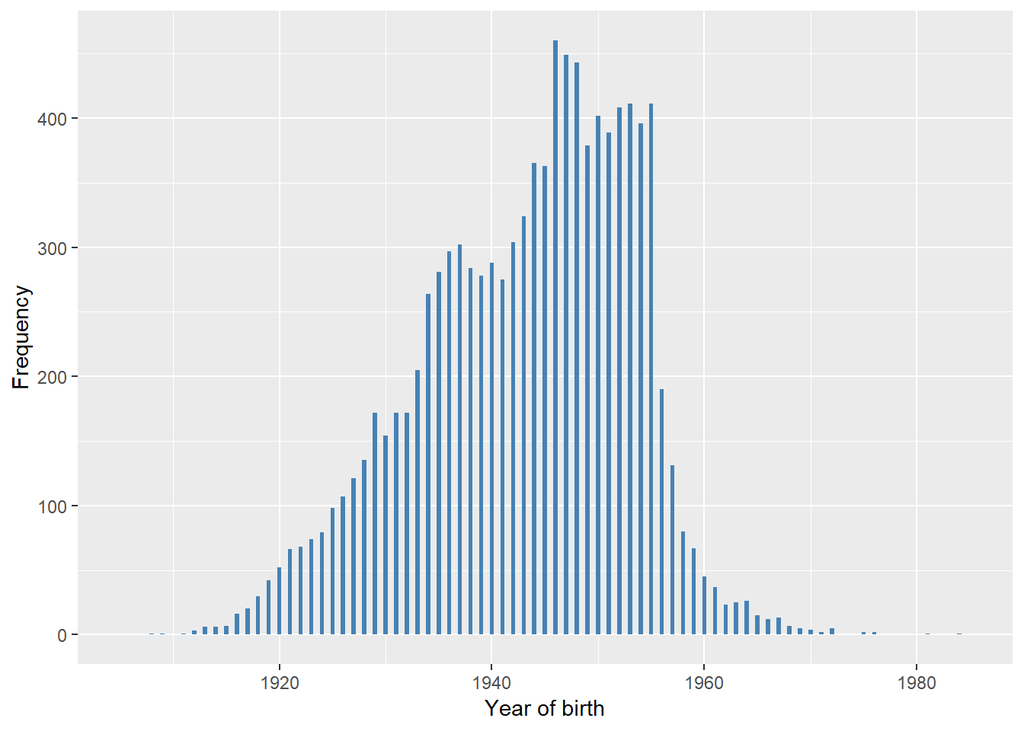

#### 2.1.5.2 Harmonisation algorithm

To compute `mi_ha` from the study-specific variable it has to be recoded as follows:

- `hedimmi == 1 into 1`
- `hedimmi == -9 into 997`
- `hedimmi == -8 into 998`
- `hedimmi == 0 into 0`

To compute `mi_ha_age` from the study-specific variable it has to be recoded as follows:

- `if mi_ha == 1, mi_ha_age = heagbry - ybirth`
- `if mi_ha == 0, mi_ha_age = 996`
- `-9 into 997`
- `-8 into 998`
- `-1 into 996`
- `otherwise, mi_ha_age = 999`

**R script:**

```r
# Categorical variable harmonization
ELSA_ds_w5 <- tibble(id = ELSA_w5$id)
ELSA_ds_w5$mi_ha <- car::recode(ELSA_w5$hedimmi, "-8=998;-9=997")

# Continuous variable harmonization
ELSA_ds_w5$mi_ha_age <- rep(999, length(ELSA_w5$id))
ELSA_ds_w5$mi_ha_age[which(ELSA_ds_w5$mi_ha == 0)] <- 996
ELSA_ds_w5$mi_ha_age[which(ELSA_ds_w5$mi_ha == 1 & !ELSA_w5$heagbry %in% c(-1,
    -8, -9))] <- ELSA_w5$heagbry[which(ELSA_ds_w5$mi_ha == 1 & !ELSA_w5$heagbry %in%
    c(-1, -8, -9))] - ELSA_w5$ybirth[which(ELSA_ds_w5$mi_ha == 1 & !ELSA_w5$heagbry %in%
    c(-1, -8, -9))]
ELSA_ds_w5$mi_ha_age <- car::recode(ELSA_ds_w5$mi_ha_age, "-1=996;-8=998;-9=997;NA=999")
```

#### 2.1.5.3 Statistics of the new harmonized variable

Myocardial infarction or heart attack

| Sample size | Missing values |
| --- | --- |
| 10274 | 15 |

Category

|  | 0 | 1 |
| --- | --- | --- |
| Frequency | 10137.00 | 122.00 |
| Percentage | 98.67 | 1.19 |

Type of missing

|  | 991 | 992 | 993 | 994 | 995 | 996 | 997 | 998 | 999 | NA |
| --- | --- | --- | --- | --- | --- | --- | --- | --- | --- | --- |
| Frequency | 0 | 0 | 0 | 0 | 0 | 0 | 4.00 | 11.00 | 0 | 0 |
| Percentage | 0 | 0 | 0 | 0 | 0 | 0 | 0.04 | 0.11 | 0 | 0 |

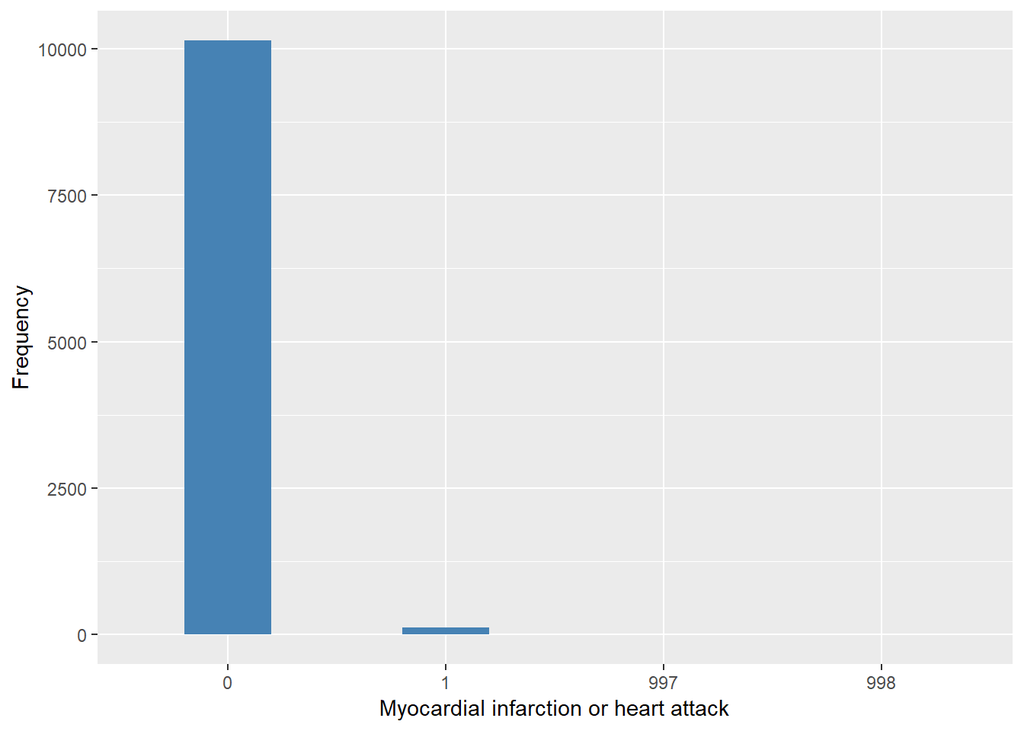

Age of each episode of myocardial infarction or heart attack

| Sample size | Missing values |
| --- | --- |
| 10274 | 10199 |

Values

|  | No-missings | 991 | 992 | 993 | 994 | 995 | 996 | 997 | 998 | 999 | NA |
| --- | --- | --- | --- | --- | --- | --- | --- | --- | --- | --- | --- |
| Frequency | 75.00 | 0 | 0 | 0 | 0 | 0 | 10137.00 | 0 | 0 | 62.0 | 0 |
| Percentage | 0.73 | 0 | 0 | 0 | 0 | 0 | 98.67 | 0 | 0 | 0.6 | 0 |

Summary

| Min. | 1st Qu. | Median | Mean | 3rd Qu. | Max. |
| --- | --- | --- | --- | --- | --- |
| 46 | 59 | 68 | 68.93 | 77.5 | 94 |

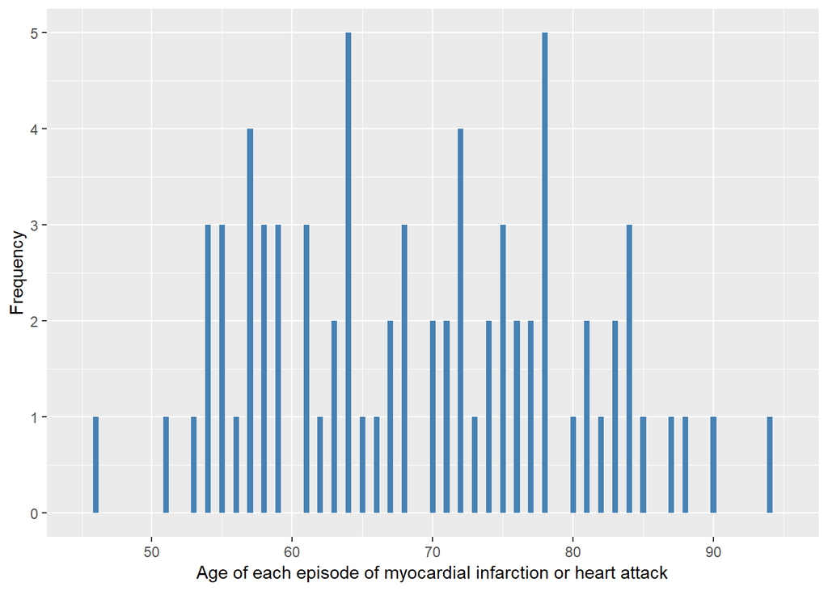

#### 2.1.5.4 Validation

|  | hedimmi==0->0 | hedimmi==1->1 | hedimmi==-9->997 | hedimmi==-8->998 |
| --- | --- | --- | --- | --- |
| BeforeH | 10137 | 122 | 4 | 11 |
| AfterH | 10137 | 122 | 4 | 11 |

### 2.1.6 Wave 6

#### 2.1.6.1 Study-specific variable description

| **Name** | `hedimmi` | `ybirth` | `HeAgbRY` |
| --- | --- | --- | --- |
| **Label** | `CVD: heart attack diagnosis newly reported (merged)` | `year of birth` | `Year told had heart attack since last interview` |
| **Table name** | `wave_6_elsa_data_v2` | `elsa_w6_hd` | `wave_6_elsa_data_v2` |
| **Categories** | `1 = Mentioned` `0 = Not mentioned` | `continuous` | `continuous` |
| **Missings** | `-9 = Refusal` `-8 = Don't know` `-1 = Not applicable` |  | `-9 = Refusal` `-8 = Don't know` `-1 = Not applicable` |
| **Description** |  |  |  |

hedimmi

| Sample size | Missing values |
| --- | --- |
| 10601 | 11 |

Category

|  | 0 | 1 |
| --- | --- | --- |
| Frequency | 10462.00 | 128.00 |
| Percentage | 98.69 | 1.21 |

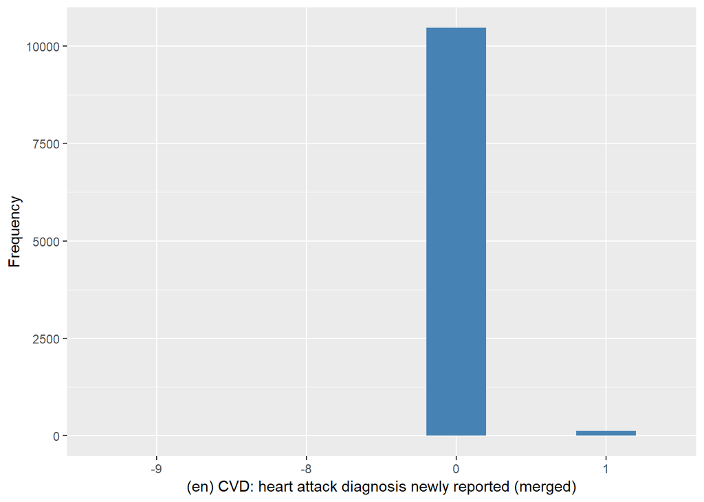

HeAgbRY

| Sample size | Missing values |
| --- | --- |
| 10601 | 10528 |

Summary

| Min. | 1st Qu. | Median | Mean | 3rd Qu. | Max. |
| --- | --- | --- | --- | --- | --- |
| 2001 | 2011 | 2011 | 2011 | 2012 | 2012 |

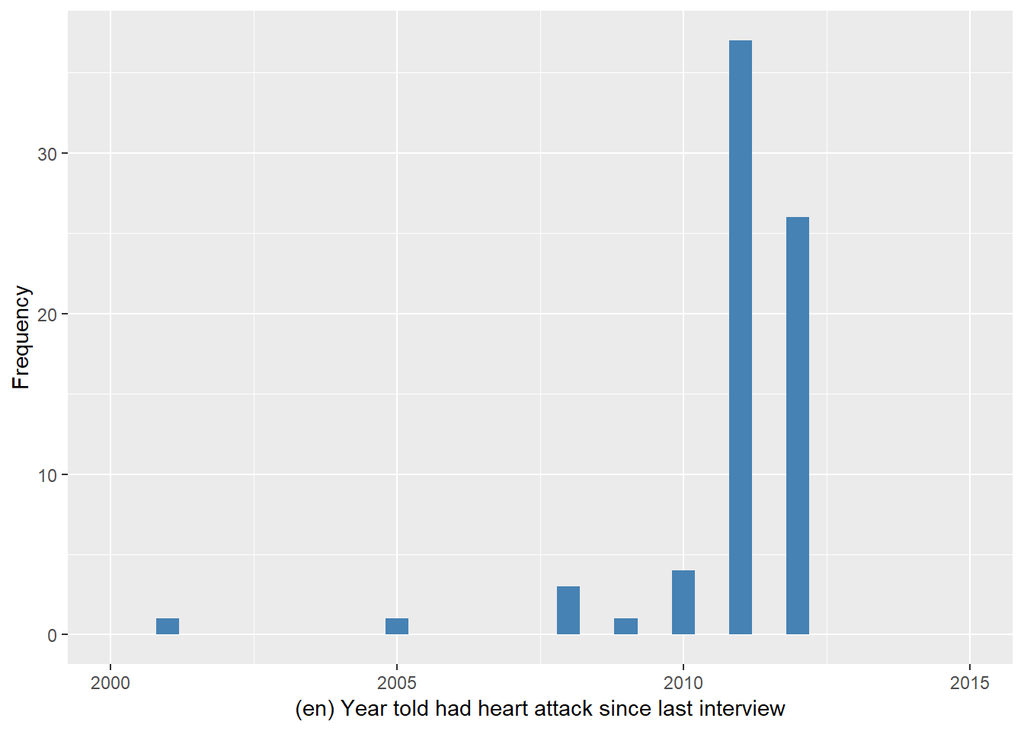

ybirth

| Sample size | Missing values |
| --- | --- |
| 10601 | 0 |

Summary

| Min. | 1st Qu. | Median | Mean | 3rd Qu. | Max. |
| --- | --- | --- | --- | --- | --- |
| 1911 | 1938 | 1946 | 1945 | 1953 | 1984 |

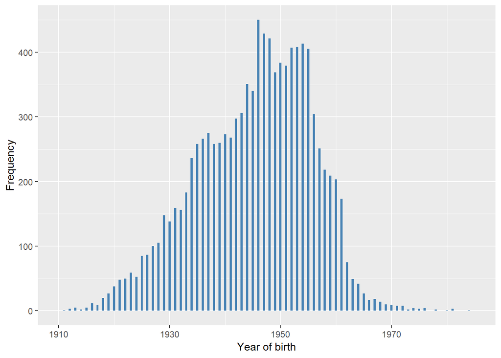

#### 2.1.6.2 Harmonisation algorithm

To compute `mi_ha` from the study-specific variable it has to be recoded as follows:

- `hedimmi == 1 into 1`
- `hedimmi == -9 into 997`
- `hedimmi == -8 into 998`
- `hedimmi == 0 into 0`

To compute `mi_ha_age` from the study-specific variable it has to be recoded as follows:

- `if mi_ha == 1, mi_ha_age = HeAgbRY - ybirth`
- `if mi_ha == 0, mi_ha_age = 996`
- `-9 into 997`
- `-8 into 998`
- `-1 into 996`
- `otherwise, mi_ha_age = 999`

**R script:**

```r
# Categorical variable harmonization
ELSA_ds_w6 <- tibble(id = ELSA_w6$id)
ELSA_ds_w6$mi_ha <- car::recode(ELSA_w6$hedimmi, "-8=998;-9=997")

# Continuous variable harmonization
ELSA_ds_w6$mi_ha_age <- rep(999, length(ELSA_w6$id))
ELSA_ds_w6$mi_ha_age[which(ELSA_ds_w6$mi_ha == 0)] <- 996
ELSA_ds_w6$mi_ha_age[which(ELSA_ds_w6$mi_ha == 1 & !ELSA_w6$HeAgbRY %in% c(-1,
    -8, -9))] <- ELSA_w6$HeAgbRY[which(ELSA_ds_w6$mi_ha == 1 & !ELSA_w6$HeAgbRY %in%
    c(-1, -8, -9))] - ELSA_w6$ybirth[which(ELSA_ds_w6$mi_ha == 1 & !ELSA_w6$HeAgbRY %in%
    c(-1, -8, -9))]
ELSA_ds_w6$mi_ha_age <- car::recode(ELSA_ds_w6$mi_ha_age, "-1=996;-8=998;-9=997;NA=999")
```

#### 2.1.6.3 Statistics of the new harmonized variable

Myocardial infarction or heart attack

| Sample size | Missing values |
| --- | --- |
| 10601 | 11 |

Category

|  | 0 | 1 |
| --- | --- | --- |
| Frequency | 10462.00 | 128.00 |
| Percentage | 98.69 | 1.21 |

Type of missing

|  | 991 | 992 | 993 | 994 | 995 | 996 | 997 | 998 | 999 | NA |
| --- | --- | --- | --- | --- | --- | --- | --- | --- | --- | --- |
| Frequency | 0 | 0 | 0 | 0 | 0 | 0 | 4.00 | 7.00 | 0 | 0 |
| Percentage | 0 | 0 | 0 | 0 | 0 | 0 | 0.04 | 0.07 | 0 | 0 |

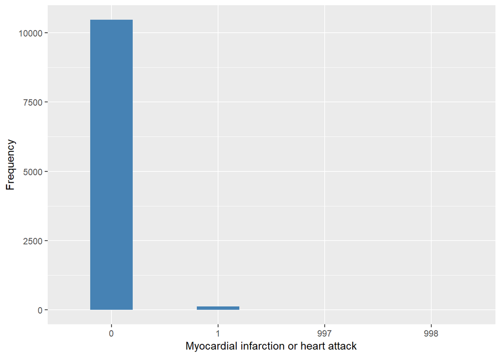

Age of each episode of myocardial infarction or heart attack

| Sample size | Missing values |
| --- | --- |
| 10601 | 10528 |

Values

|  | No-missings | 991 | 992 | 993 | 994 | 995 | 996 | 997 | 998 | 999 | NA |
| --- | --- | --- | --- | --- | --- | --- | --- | --- | --- | --- | --- |
| Frequency | 73.00 | 0 | 0 | 0 | 0 | 0 | 10462.00 | 0 | 0 | 66.00 | 0 |
| Percentage | 0.69 | 0 | 0 | 0 | 0 | 0 | 98.69 | 0 | 0 | 0.62 | 0 |

Summary

| Min. | 1st Qu. | Median | Mean | 3rd Qu. | Max. |
| --- | --- | --- | --- | --- | --- |
| 54 | 64 | 71 | 71.64 | 79 | 93 |

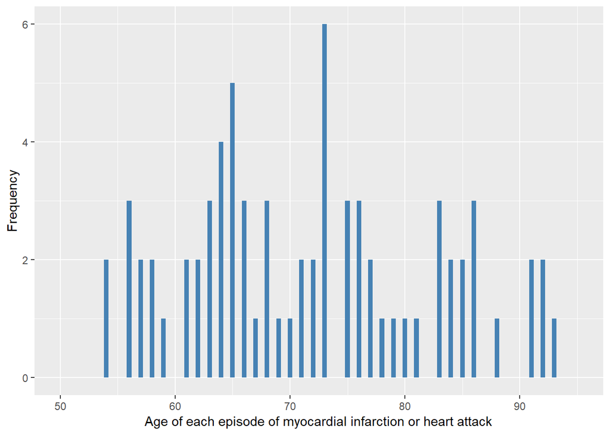

#### 2.1.6.4 Validation

|  | hedimmi==0->0 | hedimmi==1->1 | hedimmi==-9->997 | hedimmi==-8->998 |
| --- | --- | --- | --- | --- |
| BeforeH | 10462 | 128 | 4 | 7 |
| AfterH | 10462 | 128 | 4 | 7 |

### 2.1.7 Wave 7

#### 2.1.7.1 Study-specific variable description

| **Name** | `hedimmi` | `ybirth` | `HeAgbRY` |
| --- | --- | --- | --- |
| **Label** | `CVD: heart attack diagnosis newly reported (merged)` | `year of birth` | `Year told had heart attack since last interview` |
| **Table name** | `wave_7_elsa_data` | `elsa_w7_hd` | `wave_7_elsa_data` |
| **Categories** | `1 = Mentioned` `0 = Not mentioned` | `continuous` | `continuous` |
| **Missings** | `-9 = Refusal` `-8 = Don't know` `-1 = Not applicable` |  | `-9 = Refusal` `-8 = Don't know` `-1 = Not applicable` |
| **Description** |  |  |  |

hedimmi

| Sample size | Missing values |
| --- | --- |
| 9666 | 6 |

Category

|  | 0 | 1 |
| --- | --- | --- |
| Frequency | 9554.00 | 106.0 |
| Percentage | 98.84 | 1.1 |

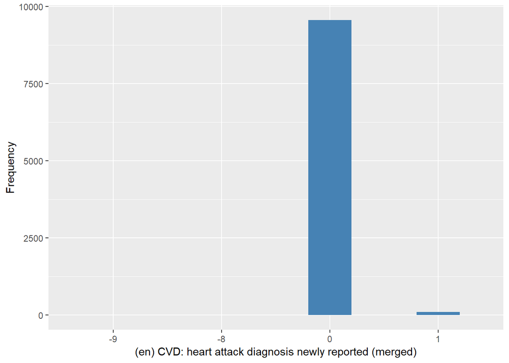

HeAgbRY

| Sample size | Missing values |
| --- | --- |
| 9666 | 9608 |

Summary

| Min. | 1st Qu. | Median | Mean | 3rd Qu. | Max. |
| --- | --- | --- | --- | --- | --- |
| 1995 | 2013 | 2014 | 2013 | 2014 | 2014 |

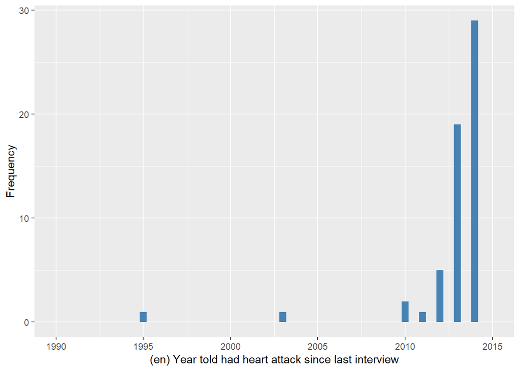

ybirth

| Sample size | Missing values |
| --- | --- |
| 9666 | 0 |

Summary

| Min. | 1st Qu. | Median | Mean | 3rd Qu. | Max. |
| --- | --- | --- | --- | --- | --- |
| 1911 | 1939 | 1947 | 1946 | 1954 | 1985 |

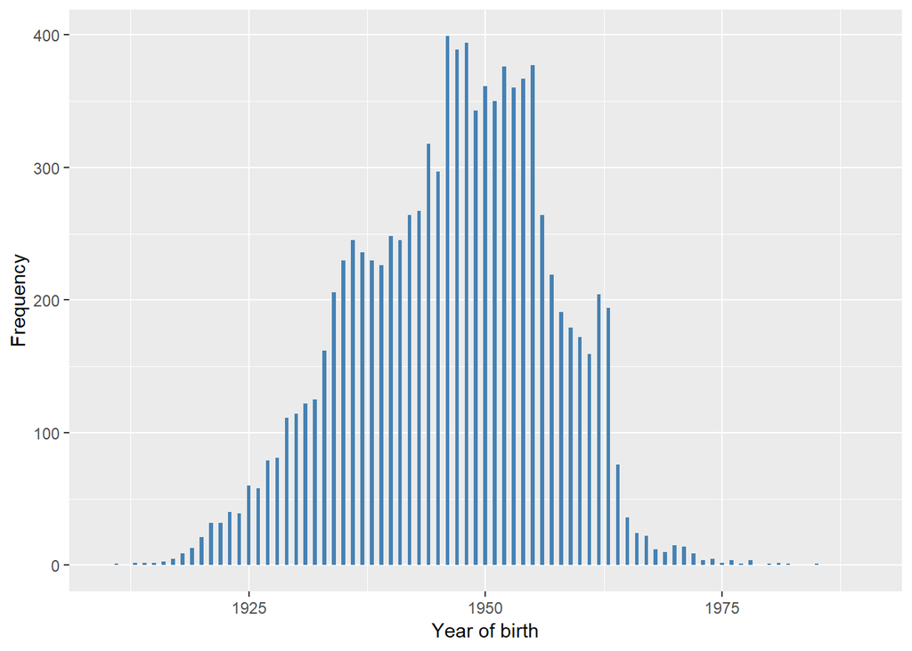

#### 2.1.7.2 Harmonisation algorithm

To compute `mi_ha` from the study-specific variable it has to be recoded as follows:

- `hedimmi == 1 into 1`
- `hedimmi == -9 into 997`
- `hedimmi == -8 into 998`
- `hedimmi == 0 into 0`

To compute `mi_ha_age` from the study-specific variable it has to be recoded as follows:

- `if mi_ha == 1, mi_ha_age = HeAgbRY - ybirth`
- `if mi_ha == 0, mi_ha_age = 996`
- `-9 into 997`
- `-8 into 998`
- `-1 into 996`
- `otherwise, mi_ha_age = 999`

**R script:**

```r
# Categorical variable harmonization
ELSA_ds_w7 <- tibble(id = ELSA_w7$id)
ELSA_ds_w7$mi_ha <- car::recode(ELSA_w7$hedimmi, "-8=998;-9=997")

# Continuous variable harmonization
ELSA_ds_w7$mi_ha_age <- rep(999, length(ELSA_w7$id))
ELSA_ds_w7$mi_ha_age[which(ELSA_ds_w7$mi_ha == 0)] <- 996
ELSA_ds_w7$mi_ha_age[which(ELSA_ds_w7$mi_ha == 1 & !ELSA_w7$HeAgbRY %in% c(-1,
    -8, -9))] <- ELSA_w7$HeAgbRY[which(ELSA_ds_w7$mi_ha == 1 & !ELSA_w7$HeAgbRY %in%
    c(-1, -8, -9))] - ELSA_w7$ybirth[which(ELSA_ds_w7$mi_ha == 1 & !ELSA_w7$HeAgbRY %in%
    c(-1, -8, -9))]
ELSA_ds_w7$mi_ha_age <- car::recode(ELSA_ds_w7$mi_ha_age, "-1=996;-8=998;-9=997;NA=999")
```

#### 2.1.7.3 Statistics of the new harmonized variable

Myocardial infarction or heart attack

| Sample size | Missing values |
| --- | --- |
| 9666 | 6 |

Category

|  | 0 | 1 |
| --- | --- | --- |
| Frequency | 9554.00 | 106.0 |
| Percentage | 98.84 | 1.1 |

Type of missing

|  | 991 | 992 | 993 | 994 | 995 | 996 | 997 | 998 | 999 | NA |
| --- | --- | --- | --- | --- | --- | --- | --- | --- | --- | --- |
| Frequency | 0 | 0 | 0 | 0 | 0 | 0 | 1.00 | 5.00 | 0 | 0 |
| Percentage | 0 | 0 | 0 | 0 | 0 | 0 | 0.01 | 0.05 | 0 | 0 |

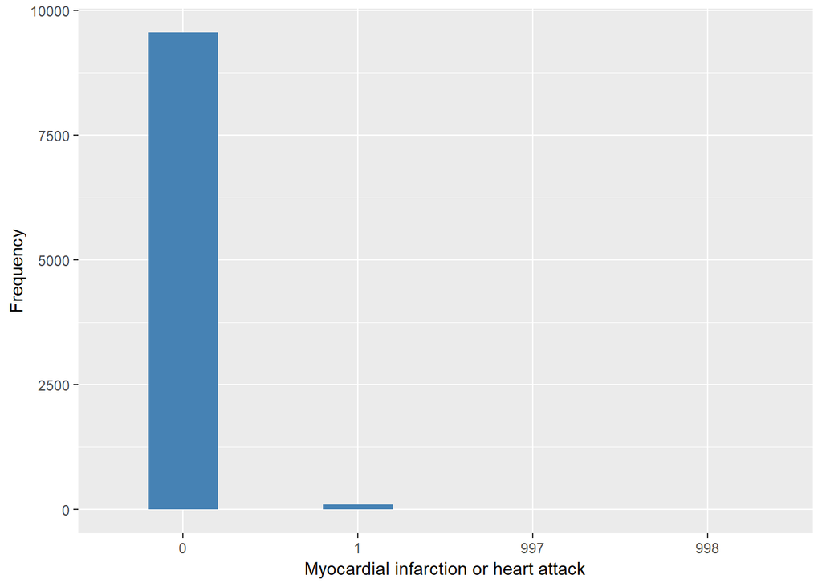

Age of each episode of myocardial infarction or heart attack

| Sample size | Missing values |
| --- | --- |
| 9666 | 9608 |

Values

|  | No-missings | 991 | 992 | 993 | 994 | 995 | 996 | 997 | 998 | 999 | NA |
| --- | --- | --- | --- | --- | --- | --- | --- | --- | --- | --- | --- |
| Frequency | 58.0 | 0 | 0 | 0 | 0 | 0 | 9554.00 | 0 | 0 | 54.00 | 0 |
| Percentage | 0.6 | 0 | 0 | 0 | 0 | 0 | 98.84 | 0 | 0 | 0.56 | 0 |

Summary

| Min. | 1st Qu. | Median | Mean | 3rd Qu. | Max. |
| --- | --- | --- | --- | --- | --- |
| 43 | 61 | 67.5 | 69.28 | 77.75 | 93 |

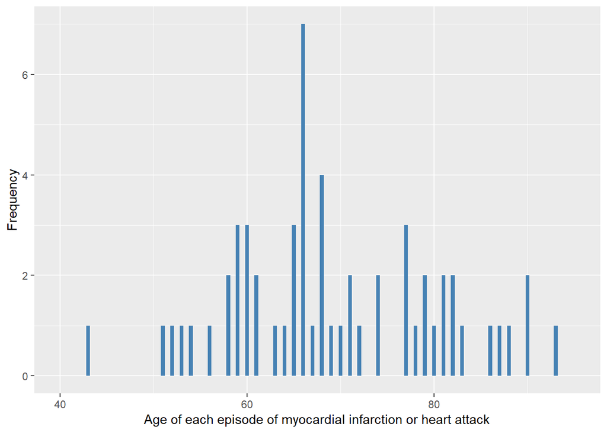

#### 2.1.7.4 Validation

|  | hedimmi==0->0 | hedimmi==1->1 | hedimmi==-9->997 | hedimmi==-8->998 |
| --- | --- | --- | --- | --- |
| BeforeH | 9554 | 106 | 1 | 5 |
| AfterH | 9554 | 106 | 1 | 5 |

## 2.2 Descriptive statistics of the harmonised variable `mi_ha` accross populations and waves

Two tables are generated:

1. Percentages of categories in each harmonised variable.
2. Frequencies and percentages of individuals with different trajectories. To avoid too large table, Only trajectories with percentages larger than 0.3 are shown.

Myocardial infarction or heart attack

| val | label | W1 | W2 | W3 | W4 | W5 | W6 | W7 |
| --- | --- | --- | --- | --- | --- | --- | --- | --- |
| 0 | No | 94.12 | 98.51 | 98.81 | 98.59 | 98.67 | 98.69 | 98.84 |
| 1 | Yes | 5.8 | 1.4 | 1.14 | 1.27 | 1.19 | 1.21 | 1.1 |
| 991 | CAPI interviewer error | 0 | 0 | 0 | 0 | 0 | 0 | 0 |
| 992 | Impute | 0 | 0 | 0 | 0 | 0 | 0 | 0 |
| 993 | Disable to measure | 0 | 0 | 0 | 0 | 0 | 0 | 0 |
| 994 | Not attempt not done | 0 | 0 | 0 | 0 | 0 | 0 | 0 |
| 995 | Does not answer | 0 | 0 | 0 | 0 | 0 | 0 | 0 |
| 996 | Not applicable | 0 | 0 | 0.05 | 0 | 0 | 0 | 0 |
| 997 | Refuse | 0.02 | 0.01 | 0 | 0.06 | 0.04 | 0.04 | 0.01 |
| 998 | Do not know | 0.05 | 0.08 | 0 | 0.08 | 0.11 | 0.07 | 0.05 |
| 999 | Missing | 0 | 0 | 0 | 0 | 0 | 0 | 0 |
| NA | NA | 0 | 0 | 0 | 0 | 0 | 0 | 0 |
| n | sample size | 12099 | 9432 | 9771 | 11050 | 10274 | 10601 | 9666 |

|  | val | frq | raw.prc |
| --- | --- | --- | --- |
| 1 | 0000000 | 4057 | 21.94 |
| 3 | 000000NA | 610 | 3.30 |
| 7 | 00000NA0 | 62 | 0.34 |
| 8 | 00000NANA | 442 | 2.39 |
| 13 | 0000NA00 | 61 | 0.33 |
| 17 | 0000NANANA | 546 | 2.95 |
| 28 | 000NA000 | 116 | 0.63 |
| 30 | 000NA00NA | 59 | 0.32 |
| 40 | 000NANANANA | 822 | 4.45 |
| 51 | 00NA0000 | 104 | 0.56 |
| 76 | 00NANANANANA | 1183 | 6.40 |
| 95 | 0NA00000 | 90 | 0.49 |
| 113 | 0NA0NANANANA | 109 | 0.59 |
| 119 | 0NANA0000 | 70 | 0.38 |
| 132 | 0NANANA000 | 57 | 0.31 |
| 143 | 0NANANANANANA | 1903 | 10.29 |
| 144 | 1000000 | 131 | 0.71 |
| 170 | 100NANANANA | 67 | 0.36 |
| 188 | 10NANANANANA | 82 | 0.44 |
| 220 | 1NANANANANANA | 180 | 0.97 |
| 247 | NANA00000 | 838 | 4.53 |
| 249 | NANA0000NA | 113 | 0.61 |
| 252 | NANA000NANA | 82 | 0.44 |
| 258 | NANA00NANANA | 121 | 0.65 |
| 264 | NANA0NA000 | 56 | 0.30 |
| 277 | NANA0NANANANA | 300 | 1.62 |
| 289 | NANANA0000 | 1640 | 8.87 |
| 291 | NANANA000NA | 245 | 1.33 |
| 295 | NANANA00NANA | 177 | 0.96 |
| 305 | NANANA0NANANA | 346 | 1.87 |
| 316 | NANANANA000 | 80 | 0.43 |
| 325 | NANANANANA00 | 925 | 5.00 |
| 327 | NANANANANA0NA | 260 | 1.41 |
| 331 | NANANANANANA0 | 498 | 2.69 |

## 2.3 Summary of descriptive statistics of the harmonised variable `mi_ha_age` accross populations and waves

Age of each episode of myocardial infarction or heart attack

| mi_ha_age | W1 | W2 | W3 | W4 | W5 | W6 | W7 |
| --- | --- | --- | --- | --- | --- | --- | --- |
| Min. | 16 | 52 | 42 | 28 | 46 | 54 | 43 |
| 1st Qu. | 53 | 61 | 62.75 | 63.75 | 59 | 64 | 61 |
| Median | 61 | 68.5 | 71 | 75.5 | 68 | 71 | 67.5 |
| Mean | 60.29 | 69.67 | 70.54 | 72.17 | 68.93 | 71.64 | 69.28 |
| 3rd Qu. | 69 | 78 | 77 | 81.25 | 77.5 | 79 | 77.75 |
| Max. | 91 | 91 | 92 | 95 | 94 | 93 | 93 |
| No-missings | 501 | 114 | 68 | 60 | 75 | 73 | 58 |
| 991 | 0 | 0 | 0 | 0 | 0 | 0 | 0 |
| 992 | 0 | 0 | 0 | 0 | 0 | 0 | 0 |
| 993 | 0 | 0 | 0 | 0 | 0 | 0 | 0 |
| 994 | 0 | 0 | 0 | 0 | 0 | 0 | 0 |
| 995 | 0 | 0 | 0 | 0 | 0 | 0 | 0 |
| 996 | 11587 | 9291 | 9655 | 10894 | 10137 | 10462 | 9554 |
| 997 | 1 | 0 | 0 | 0 | 0 | 0 | 0 |
| 998 | 1 | 0 | 0 | 0 | 0 | 0 | 0 |
| 999 | 9 | 27 | 48 | 96 | 62 | 66 | 54 |
| NA | 0 | 0 | 0 | 0 | 0 | 0 | 0 |
| sample size | 12099 | 9432 | 9771 | 11050 | 10274 | 10601 | 9666 |

# 3 Quality estimation

No comments